# Coursework #2 AI for Sustainable Development

## Coursework overview

Coursework #2 is a data analysis coding-based coursework. You are asked to choose a dataset related to sustainable development and do some machine learning based analysis. We will detail this more in the next sections.

You can choose an application/dataset from the ones we analysed in the first coursework or choose a completely new dataset:

- **Option 1**: Choose a dataset from the SustainBench paper (which includes 15 datasets related to sustainable development), please do not choose the climate action one related to brick kilns, as we will use it in class.

You can choose the same dataset that you use in coursework #1. Please note that the authors from SustainBench have a GitHub project with data loaders, preprocessing code and baselines for these datasets here: https://github.com/sustainlab-group/sustainbench

- **Option 2**: Choose an alternative dataset of your choice (e.g. that you are interested in). Please if you choose this option motivate the dataset's relationship to sustainable development. If the dataset is part of an online competition (e.g. in Kaggle, Zindi, etc), please make sure to include information that makes us discern what you have built, vs what was built from someone else (since in some cases participants of the competition submit tutorials, etc).

Please do NOT choose the same dataset that you used as part of a different coursework for a different module (which may be possible as the coursework is up to some extent open ended), as this would be considered self-plagiarism.

Once you have chosen your dataset we will ask you to do the following:

1. Do some **exploratory data analysis** to get some insights about the dataset. We do not give specific guidelines here as this may depend on the dataset itself, but we ask you to justify your choices and the results of your analysis.
2. Think about the **task that the dataset is most suitable for** and discuss what would be the most **appropriate evaluation criteria** for such a machine learning task. For example, you may have a dataset where songs are labelled with different music genres. Perhaps the task for which the dataset is most suitable for is to build a multi label prediction model that can classify new songs, and the most appropriate evaluation metric could be the hamming loss (commonly used in multi label prediction, which could be used both as inspiration for a training objective for neural networks, or simply as the evaluation criteria for model selection and hyperparameter tuning).
3. **Design and implement a machine learning system/pipeline**. This could be either supervised or unsupervised. In either case, the pipeline you choose needs to be aligned with the task you defined before.
4. **Design a set of experiments** and discuss how these fit with the questions that the dataset aims to address. Do a **performance & scalability analysis** of your model.
5. Analyse and discuss some of the **ethical implications**, in connection with your exploratory data analysis and model performance (e.g. do you appreciate any imbalances in the data or initial biases that can be problematic?).
6. Discuss **sustainable development relevance & impact**.

We ask your code to be in python, but beyond that we do not mind what packages you use.

For grading, we will not check your code in depth (beyond perhaps checking that it's doing what you describe). Instead, our focus will be on grading the analysis you have done, how well it's motivated and justified, how insightful it was, how do you interpret the results in terms of impact and sustainable development, etc.

**Submission**: You do not have to submit your dataset and notebook to the coursework submission. Simply run the analysis in jupyter notebooks and then export the notebook as html or pdf. You can then submit this html/pdf file in moodle.

### Previous work (5%)

**Guidelines**: We first ask you to summarise what has been done before with this dataset. While this is not specifically necessary for the purpose of the coursework, it is important for us to mark the novelty of your analysis, specially since many of these datasets come with associated baselines in the GitHub link we shared before. While we encourage you to compare to what has been done before we will evaluate whether you explored new approaches. Please give us in this section a brief introduction to the dataset and to the previous models that were built before using the data (you do not need to go over all models that were proposed before, you can just focus on the one with the best performance). Tell us whether these models were publicly available, and if so where to find them. It is crucial that in the next sections you justify how your analysis differs from this previous work.

**[Answer below]**

I chose the dataset from Kaggle (https://www.kaggle.com/datasets/hopesb/student-depression-dataset) [3], which was uploaded on November 22, 2024. As this dataset is relatively new, there are no prior publicly available analyses or baselines for reference or comparison when conducting my analysis and modeling.

This student depression dataset is structured as a CSV file. Each row represents data for an individual student information, with a total of 27,901 rows. Each column corresponds to a specific feature or attribute, with a total of 18 columns. Among them, the first 17 columns represent potential factors related to whether a student is experiencing depression, while the 18th column serves as a binary target variable indicating whether the student is depressed.

### Exploratory data analysis (15%)

**Guidelines**: Load the dataset and answer the following questions:

- What are the characteristics of your dataset? Do you see any trends in the data? (5%)
- Are there any challenges with the data? (missing values, outliers, imbalanced classes, biases, etc...) (5%)
- Does the data need any pre-processing to successfully apply standard machine learning models? If so, what kind? Please do the pre-processing that you consider necessary. (5%)

You can use descriptive statistics here, figures/plots, etc.

**Characteristics of Dataset**

This original dataset consists of 27,901 rows and 18 columns, of which the first 17 columns are features and the 18th column is the target variable. The meanings and data types of all features and target variables are respectively:

id: Unique identifier for each student. (int64)

Gender: Gender of each student. (object)

Age: Age of each student. (float64)

City: Geographic region. (object)

Profession: Occupation of each individual. (object)

Academic Pressure: The level of academic pressure. (float64)

Work Pressure: The level of work pressure. (float64)

CGPA: Grade Point Average or other academic scores. (float64)

Study Satisfaction: Overall satisfaction rating with the learning experience and outcomes during the learning process. (float64)

Job Satisfaction: Overall satisfaction rating with the working experience and outcomes during the working process. (float64)

Sleep Duration: Average daily sleep duration. (object)

Dietary Habits: Healthiness of daily diet. (object)

Degree: Current grade level or degree being pursued. (object)

Have you ever had suicidal thoughts? (object)

Work/Study Hours: Hours of study or work per day. (float64)

Financial Stress: Levels of stress over living costs, tuition or other expenses. (float64)

Family History of Mental Illness: Any history of mental illness in the family. (object)

Depression: Whether the respondent is depressed. (object)

**Handling Missing Values and Quantitative Analysis of the Dataset (Sample Data of 2790 x 18)**

Due to time and resource constraints, I selected 10% of the total 27,901 rows (i.e., 2,790 rows) as a sample for analysis. Before sampling, three rows containing missing values in the "Financial Pressure" feature were removed entirely. As a result, the 2,790-row sample dataset does not contain any missing values.

ID Distribution: The ID values range between 0 and 140,000 and are evenly distributed across the intervals with no significant trends. The correlation between the ID feature and the target variable is 0.012, which is close to zero, indicating almost no relationship. Consequently, the ID feature was removed during data cleaning.

Gender Distribution: Males account for 55.7% of the dataset, while females make up 44.3%. The male proportion is slightly higher than the female proportion.

Age Distribution: Only one entry falls outside the 18–36 range, with a value of 48.0. Based on the boxplot, this value is identified as an outlier and was removed during data cleaning.

City Distribution: Students from Kalyan represent the largest proportion at 6.0%, while Vaanya, Rashi, M.com, Khaziabad, and Bhavna each have only one entry.

Profession Distribution: "Student" accounts for 2789 out of 2790 rows, with "Education Consultant" making up just 1 entry. Given this binary distribution, where the "Student" category dominates nearly 100%, the "Profession" feature provides minimal meaningful variation and was removed during data cleaning.

Academic Pressure Distribution: Academic stress is categorized into five levels (1, 2, 3, 4, 5), with Level 3 being the most common at 28.7%, and Level 2 being the least common at 13.9%.

Work Pressure Distribution: All entries in the dataset report a value of 0 for work stress, indicating no work-related stress among participants. This feature was deemed uninformative and removed during data cleaning.

CGPA Distribution: CGPA values range from 5 to 10 and are relatively evenly distributed.

Academic Satisfaction Distribution: Academic satisfaction is categorized into five levels (1, 2, 3, 4, 5) and is approximately evenly distributed, with each level accounting for roughly 20% of the data.

Work Satisfaction Distribution: Similar to work stress, all entries report a value of 0 for work satisfaction, aligning with the absence of work stress. This feature was also removed during data cleaning.

Daily Sleep Duration Distribution: Sleep duration is categorized into five groups: less than 5 hours, 5–6 hours, 7–8 hours, more than 8 hours, and "Other." The "Other" category contains only one entry and was removed during data cleaning. The most common sleep duration is less than 5 hours, accounting for 30.4% of the data.

Dietary Habits Distribution: Dietary habits are categorized into four groups: unhealthy, moderately healthy, healthy, and "Other." The "Other" category contains only two entries and was removed during data cleaning. The most common dietary habit is "unhealthy," comprising 37.9% of the data, while "healthy" is the least common at 27.0%.

Academic Degree Distribution: There are 28 categories in this feature. "Class 12" is the most frequent, with 620 entries accounting for 22.2% of the data.

Suicidal Thoughts Distribution: 64.1% of participants reported having suicidal thoughts, while 35.9% reported not having any.

Study/Work Hours Distribution: Study/work hours are categorized into 13 integer levels (0–12, inclusive). The most common value is 10 hours per day, with 455 entries (16.3%).

Financial Pressure Distribution: Financial pressure is categorized into five levels (1, 2, 3, 4, 5), with Level 5 being the most common, accounting for 706 entries (25.3%).

Family History of Mental Illness Distribution: 52.5% of participants reported no family history of mental illness, while 47.5% reported a positive family history.

Depression (Target Variable) Distribution: 41.6% of participants were classified as "not depressed," while 58.4% were classified as "depressed."

**Data Cleaning**

In the original dataset of 27,901 rows and 18 columns, the feature "Financial Pressure" contained 3 missing values. To address this, I chose to remove the entire rows with missing values, reducing the dataset to 27,898 rows. From these, 10% (2,790 rows) were randomly selected as the sample data for analysis.

Within this 2,790-row sample dataset:

- One entry contained an outlier in the "Age" feature.
- One entry belonged to the "Other" category in "Sleep Duration," which was negligible.
- Two entries belonged to the "Other" category in "Dietary Habits," which were also negligible.

These 4 rows were removed, resulting in 2,786 rows of clean data for modeling. Additionally, the following features were deemed uninformative (as previously discussed) and removed entirely:

- ID
- Profession
- Work Stress
- Work Satisfaction

After removing these four columns, the dataset dimensions were reduced to 2,786 rows and 14 columns.

**Data Preprocessing (Sample Data of 2786 x 14)**

Following data cleaning, the next step was data preprocessing. Due to the variations in data types and value ranges across features, preprocessing was performed to standardize the structure and value ranges of all features. This ensured compatibility with multiple machine learning models, such as Random Forest, SVM, Decision Tree, KNN. Standardizing the value ranges also ensured that different algorithms treated all features fairly without biases arising from differing scales.

Steps in Preprocessing:

1. Numerical Encoding:

For categorical features with object data types, numerical values were assigned to each category. For example, unique numbers were assigned to different categories in features such as "City" and "Dietary Habits."

2. Normalization:

For features with int64 and float64 data types, Min-Max normalization was applied to scale values to the [0, 1] range. For categorical features encoded as numbers, Min-Max normalization was also applied after encoding.

These steps ensured that all features in the processed dataset were of type float64 with values normalized between 0 and 1. This uniform preprocessing enabled the dataset to be optimally used across different machine learning models.

```python
# Step 1: Mount Google Drive
from google.colab import drive
drive.mount('/content/drive')

# Step 3: Import kagglehub and download the dataset
import kagglehub
path = kagglehub.dataset_download("hopesb/student-depression-dataset")

# Step 4: Define the target path and move files
import shutil
import os

# Ensure the target folder exists
destination_folder = '/content/drive/My Drive/ai4sd/CW2'
os.makedirs(destination_folder, exist_ok=True)

# Remove existing files in the target path
for file_name in os.listdir(path):
    destination_path = os.path.join(destination_folder, file_name)
    if os.path.exists(destination_path):
        os.remove(destination_path)
    shutil.move(os.path.join(path, file_name), destination_folder)

print("Dataset files moved to:", destination_folder)
```

```
Downloading from https://www.kaggle.com/api/v1/datasets/download/hopesb/student-depression-dataset?dataset_version_number=1...
```

```
Extracting files...
```

```
Dataset files moved to: /content/drive/My Drive/ai4sd/CW2
```

```python
import pandas as pd
import os

# Define the target folder path
destination_folder = '/content/drive/My Drive/ai4sd/CW2'

# Locate the path of the CSV file
csv_file_path = None
for file_name in os.listdir(destination_folder):
    if file_name.endswith('.csv'):
        csv_file_path = os.path.join(destination_folder, file_name)
        print("Found CSV file:", csv_file_path)
        break

# Read the CSV file
df = pd.read_csv(csv_file_path)

# Display the first 10 rows
print("First 10 rows of the dataset:")
print(df.head(10))
```

```
Found CSV file: /content/drive/My Drive/ai4sd/CW2/Student Depression Dataset.csv
First 10 rows of the dataset:
   id  Gender   Age           City Profession  Academic Pressure  \
0   2    Male  33.0  Visakhapatnam    Student                5.0
1   8  Female  24.0      Bangalore    Student                2.0
2  26    Male  31.0       Srinagar    Student                3.0
3  30  Female  28.0       Varanasi    Student                3.0
4  32  Female  25.0         Jaipur    Student                4.0
5  33    Male  29.0           Pune    Student                2.0
6  52    Male  30.0          Thane    Student                3.0
7  56  Female  30.0        Chennai    Student                2.0
8  59    Male  28.0         Nagpur    Student                3.0
9  62    Male  31.0         Nashik    Student                2.0

   Work Pressure  CGPA  Study Satisfaction  Job Satisfaction  \
```

[output cut: 46 more lines]

**Handling Missing Value**

```python
# Total number of rows counted
total_rows = df.shape[0]
print(f"\nTotal number of rows in the dataset: {total_rows}")

total_columns = df.shape[1]
print(f"\nTotal number of columns in the dataset: {total_columns}")

total_features = df.columns.tolist()
print(f"\nTotal features in the dataset: {total_features}")

last_feature_name = total_features[-1]
print(f"\nLabel: {last_feature_name}")

miss_values = df.isnull().sum().values.sum()
print(f"\nMissing values: {miss_values}")
```

```
Total number of rows in the dataset: 27901

Total number of columns in the dataset: 18

Total features in the dataset: ['id', 'Gender', 'Age', 'City', 'Profession', 'Academic Pressure', 'Work Pressure', 'CGPA', 'Study Satisfaction', 'Job Satisfaction', 'Sleep Duration', 'Dietary Habits', 'Degree', 'Have you ever had suicidal thoughts ?', 'Work/Study Hours', 'Financial Stress', 'Family …

Label: Depression

Missing values: 3
```

```python
# Check which features have missing values
missing_values = df.isnull().sum()

# Filter out features with missing values and their counts
features_with_missing = missing_values[missing_values > 0]

# Output the results
if features_with_missing.empty:
    print("No missing values in the dataset.")
else:
    print("Features with missing values and their counts:")
    print(features_with_missing)
```

```
Features with missing values and their counts:
Financial Stress    3
dtype: int64
```

```python
import pandas as pd

# Assume df is the original dataset
original_row_count = len(df)
print(f"Original dataset rows: {original_row_count}")

# Drop rows with missing values
df_cleaned = df.dropna()
print(f"Cleaned missing value dataset rows: {len(df_cleaned)}")

# Randomly sample 10% of the cleaned dataset
sampled_df = df_cleaned.sample(frac=0.1, random_state=42)

# Check the sampling result
sampled_row_count = len(sampled_df)
print(f"Sampled dataset rows: {sampled_row_count}")

# Output the result
if sampled_df.isnull().sum().sum() > 0:
    print("There are still missing values in the cleaned sample dataset!")
else:
    print("No missing values in the cleaned sample dataset.")
```

```
Original dataset rows: 27901
Cleaned missing value dataset rows: 27898
Sampled dataset rows: 2790
No missing values in the cleaned sample dataset.
```

**Characteristics and Distribution of Dataset**

```python
# Get the data type of each feature and associate it with the feature name
data_types = sampled_df.dtypes

# Output feature names and their corresponding data types
data_types_with_columns = pd.DataFrame({'Feature': sampled_df.columns, 'DataType': data_types.values})

# Print the results
print(data_types_with_columns)

# Group and count features by data type
data_type_counts = data_types.value_counts()

# Output the results
print("Data types and their counts:")
print(data_type_counts)
```

```
                                  Feature DataType
0                                      id    int64
1                                  Gender   object
2                                     Age  float64
3                                    City   object
4                              Profession   object
5                       Academic Pressure  float64
6                           Work Pressure  float64
7                                    CGPA  float64
8                      Study Satisfaction  float64
9                        Job Satisfaction  float64
10                         Sleep Duration   object
11                         Dietary Habits   object
12                                 Degree   object
13  Have you ever had suicidal thoughts ?   object
14                       Work/Study Hours  float64
15                       Financial Stress  float64
16       Family History of Mental Illness   object
17                             Depression    int64
Data types and their counts:
object     8
float64    8
int64      2
Name: count, dtype: int64
```

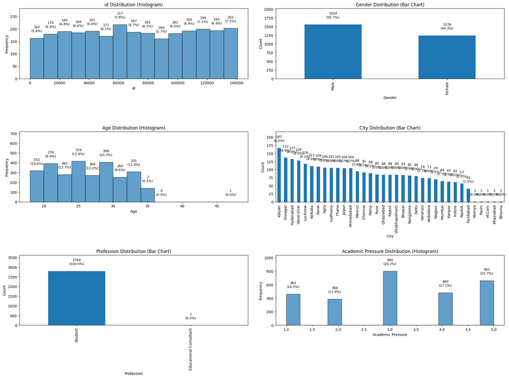

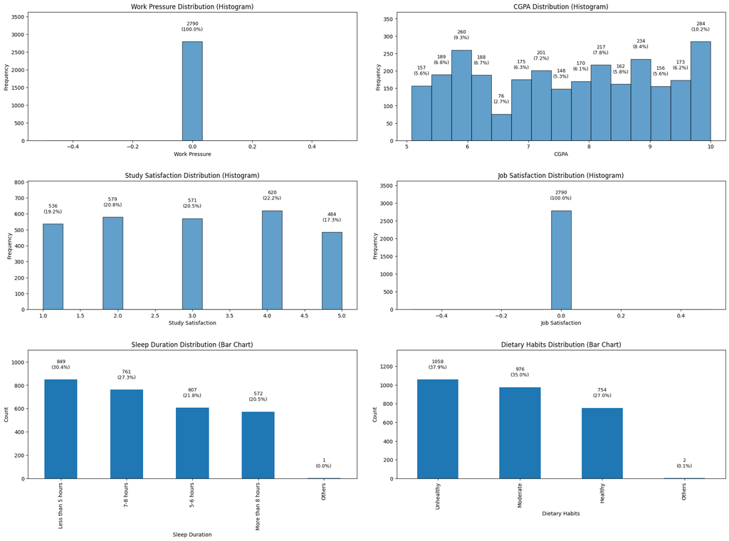

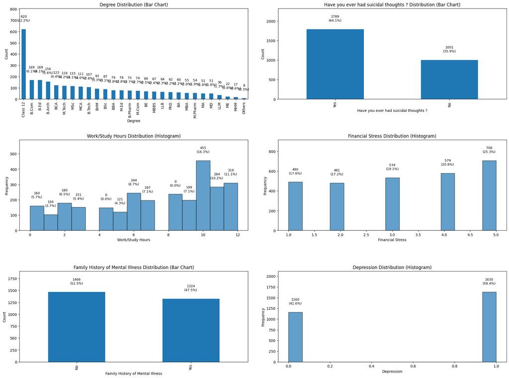

```python
import pandas as pd
import matplotlib.pyplot as plt

# Assume sampled_df is the cleaned and sampled dataset
# Check the data types of each column
data_types = sampled_df.dtypes

# Display 6 columns per page
columns_per_page = 6
total_columns = len(sampled_df.columns)
pages = (total_columns + columns_per_page - 1) // columns_per_page  # Calculate total pages

for page in range(pages):
    plt.figure(figsize=(20, 15))  # Set the figure size for each page
    start = page * columns_per_page
    end = min((page + 1) * columns_per_page, total_columns)
    for i, column in enumerate(sampled_df.columns[start:end], 1):
        plt.subplot(3, 2, i)  # Maximum 3 rows and 2 columns per page
        if data_types[column] == 'object':  # For categorical data, use a bar chart
            value_counts = sampled_df[column].value_counts()
            total = len(sampled_df[column])
            ax = value_counts.plot(kind='bar', ax=plt.gca())
            plt.title(f"{column} Distribution (Bar Chart)")
            plt.xlabel(column)
            plt.ylabel("Count")

            # Extend the y-axis range
            ax.set_ylim(0, value_counts.max() * 1.3)  # Reserve 30% extra space

            # Dynamically adjust the position of top labels
            for idx, value in enumerate(value_counts):
                percent = value / total * 100
                ax.text(idx, value + value_counts.max() * 0.1,  # Move the label upwards to avoid overlap
                        f'{value}\n({percent:.1f}%)', ha='center', va='bottom', fontsize=9)

        elif data_types[column] in ['int64', 'float64']:  # For numerical data, use a histogram
            ax = sampled_df[column].plot(kind='hist', bins=15, ax=plt.gca(), alpha=0.7, edgecolor='black')
            plt.title(f"{column} Distribution (Histogram)")
            plt.xlabel(column)
            plt.ylabel("Frequency")

            # Bin and count the data
            binned_data, bin_edges = pd.cut(sampled_df[column], bins=15, retbins=True)
            bin_counts = binned_data.value_counts(sort=False)
            total = len(sampled_df[column])

            # Extend the y-axis range
            ax.set_ylim(0, bin_counts.max() * 1.3)  # Reserve 30% extra space

            for patch, count in zip(ax.patches, bin_counts):
                left = patch.get_x() + patch.get_width() / 2
                height = patch.get_height()
                percent = count / total * 100
                if height > 0:
                    ax.text(left, height + bin_counts.max() * 0.1,  # Move the label upwards to avoid overlap
                            f'{count}\n({percent:.1f}%)', ha='center', va='bottom', fontsize=9)

    plt.tight_layout(pad=3.0)  # Adjust layout to avoid overlap between subplots
    plt.show()
```

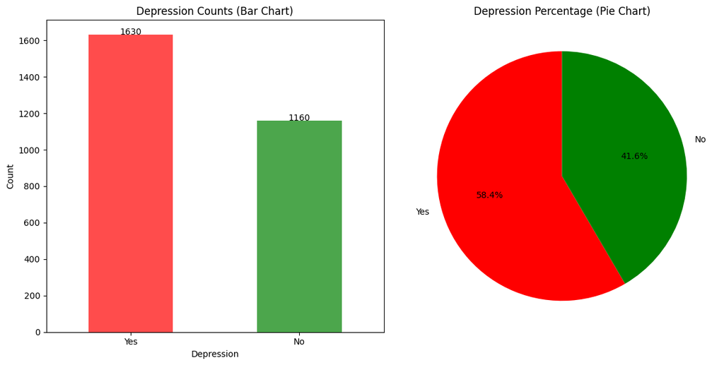

```python
import matplotlib.pyplot as plt

# Count the number of Yes and No in the Depression column
depression_counts = sampled_df['Depression'].value_counts()
depression_labels = depression_counts.index.map({1: 'Yes', 0: 'No'})  # Map numerical values to Yes and No

# Calculate percentages
depression_percentages = depression_counts / depression_counts.sum() * 100

# Create a bar chart
plt.figure(figsize=(12, 6))
plt.subplot(1, 2, 1)
depression_counts.plot(kind='bar', color=['red', 'green'], alpha=0.7)
plt.title("Depression Counts (Bar Chart)")
plt.xlabel("Depression")
plt.ylabel("Count")
plt.xticks(ticks=range(len(depression_labels)), labels=depression_labels, rotation=0)

# Display exact counts on the bar chart
for i, count in enumerate(depression_counts):
    plt.text(i, count + 1, str(count), ha='center')

# Create a pie chart
plt.subplot(1, 2, 2)
plt.pie(depression_percentages, labels=depression_labels, autopct='%1.1f%%', colors=['red', 'green'], startangle=90)
plt.title("Depression Percentage (Pie Chart)")

# Show the plots
plt.tight_layout()
plt.show()
```

**Data cleansing (from 18 dimensions to 14 dimensions)**

```python
# Calculation of correlation coefficients
correlation = sampled_df['id'].corr(sampled_df['Depression'])
print(f"Correlation between ID and Depression: {correlation}")
```

```
Correlation between ID and Depression: 0.012468618385760688
```

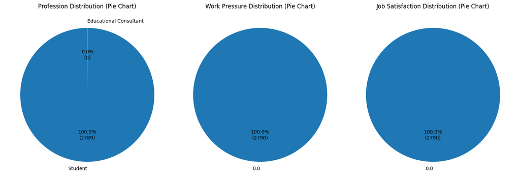

```python
import matplotlib.pyplot as plt

# Define the column names to plot as pie charts
columns_to_plot = ['Profession', 'Work Pressure', 'Job Satisfaction']

# Create subplots
plt.figure(figsize=(15, 10))

for i, column in enumerate(columns_to_plot, 1):
    plt.subplot(1, 3, i)  # Create a 1-row, 3-column subplot
    value_counts = sampled_df[column].value_counts()
    value_counts.plot(
        kind='pie',
        autopct=lambda p: f'{p:.1f}%\n({int(p * sum(value_counts) / 100)})',
        startangle=90,
        ax=plt.gca()
    )
    plt.title(f"{column} Distribution (Pie Chart)")
    plt.ylabel('')  # Hide the y-axis label

# Adjust layout
plt.tight_layout()
plt.show()
```

```python
# Columns to drop
columns_to_drop = ['id', 'Profession', 'Work Pressure', 'Job Satisfaction']

# Drop the specified columns
sampled_df_cleaned = sampled_df.drop(columns=columns_to_drop)

# Get the data type of each feature and associate it with the feature name
data_types_cleaned = sampled_df_cleaned.dtypes

# Output feature names and their corresponding data types
data_types_with_columns = pd.DataFrame({'Feature': sampled_df_cleaned.columns, 'DataType': data_types_cleaned.values})

# Print the results
print(data_types_with_columns)

# Group and count features by data type
data_type_counts = data_types_cleaned.value_counts()

# Output the results
print("Data types and their counts:")
print(data_type_counts)
```

```
                                  Feature DataType
0                                  Gender   object
1                                     Age  float64
2                                    City   object
3                       Academic Pressure  float64
4                                    CGPA  float64
5                      Study Satisfaction  float64
6                          Sleep Duration   object
7                          Dietary Habits   object
8                                  Degree   object
9   Have you ever had suicidal thoughts ?   object
10                       Work/Study Hours  float64
11                       Financial Stress  float64
12       Family History of Mental Illness   object
13                             Depression    int64
Data types and their counts:
object     7
float64    6
int64      1
Name: count, dtype: int64
```

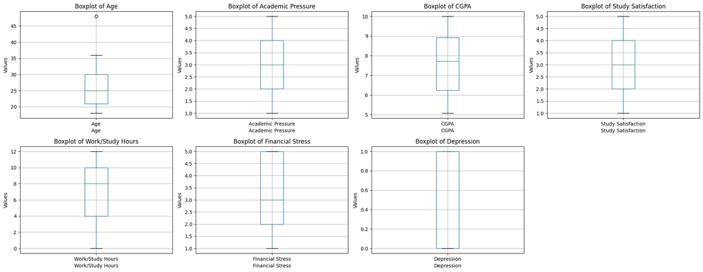

```python
import matplotlib.pyplot as plt

# Select numeric columns
numeric_columns = sampled_df_cleaned.select_dtypes(include=['int64', 'float64']).columns

# Initialize the figure
plt.figure(figsize=(20, 15))

# Iterate through numeric columns and create boxplots
for i, column in enumerate(numeric_columns, 1):
    plt.subplot(4, 4, i)  # Create subplots (4 rows x 4 columns, adjust as needed based on dimensions)
    sampled_df_cleaned.boxplot(column=column)
    plt.title(f"Boxplot of {column}")
    plt.xlabel(column)
    plt.ylabel("Values")

plt.tight_layout()  # Adjust layout to prevent overlapping
plt.show()
```

**Outlier handling and Data Cleaning (from 2790 rows to 2786 rows)**

```python
import pandas as pd

# Detect outliers and count them
def detect_outliers_with_values(df):
    outlier_info = {}  # To store outlier information
    outlier_values = {}  # To store the specific outlier values

    # Only process columns with data types int64 and float64
    numeric_columns = df.select_dtypes(include=['int64', 'float64']).columns

    for column in numeric_columns:
        Q1 = df[column].quantile(0.25)  # First quartile
        Q3 = df[column].quantile(0.75)  # Third quartile
        IQR = Q3 - Q1  # Interquartile range
        lower_bound = Q1 - 1.5 * IQR
        upper_bound = Q3 + 1.5 * IQR

        # Identify outliers
        outliers = df[(df[column] < lower_bound) | (df[column] > upper_bound)]
        outlier_count = outliers.shape[0]

        # If outliers exist, record their information
        if outlier_count > 0:
            outlier_info[column] = outlier_count
            outlier_values[column] = outliers[column].values.tolist()

    return outlier_info, outlier_values

# Detect outliers
outlier_info, outlier_values = detect_outliers_with_values(sampled_df_cleaned)

# Print outlier information and specific values
print("Features with Outliers and their Counts:")
for feature, count in outlier_info.items():
    print(f"{feature}: {count} outliers")

print("\nOutlier Values:")
for feature, values in outlier_values.items():
    print(f"{feature}: {values}")

# Remove rows with outliers
numeric_columns = sampled_df_cleaned.select_dtypes(include=['int64', 'float64']).columns
for column in outlier_info.keys():
    if column in numeric_columns:  # Only operate on numeric columns
        Q1 = sampled_df_cleaned[column].quantile(0.25)
        Q3 = sampled_df_cleaned[column].quantile(0.75)
        IQR = Q3 - Q1
        lower_bound = Q1 - 1.5 * IQR
        upper_bound = Q3 + 1.5 * IQR

        # Remove rows with outliers
        sampled_df_cleaned = sampled_df_cleaned[
            (sampled_df_cleaned[column] >= lower_bound) & (sampled_df_cleaned[column] <= upper_bound)
        ]

# Print the processed data
print("\nData after removing outliers:")
print(sampled_df_cleaned.shape)
```

```
Features with Outliers and their Counts:
Age: 1 outliers

Outlier Values:
Age: [48.0]

Data after removing outliers:
(2789, 14)
```

```python
# Remove rows where the 'Sleep Duration' column contains 'Others'
sampled_df_cleaned = sampled_df_cleaned[sampled_df_cleaned['Sleep Duration'] != 'Others']

# Remove rows where the 'Dietary Habits' column contains 'Others'
sampled_df_cleaned = sampled_df_cleaned[sampled_df_cleaned['Dietary Habits'] != 'Others']

# Output the processed data
print("\nData after removing 'Others' from Sleep Duration and Dietary Habits:")
print(sampled_df_cleaned.shape)
```

```
Data after removing 'Others' from Sleep Duration and Dietary Habits:
(2786, 14)
```

**Numerical Encoding & Normalisation**

```python
# Get unique values in the 'Gender' column and assign numbers
unique_genders = sampled_df_cleaned['Gender'].unique()
gender_mapping = {gender: idx for idx, gender in enumerate(unique_genders)}

# Map the 'Gender' column to numerical values
sampled_df_cleaned['Gender'] = sampled_df_cleaned['Gender'].map(gender_mapping)

# Get the minimum and maximum values of the 'Gender' column
gender_min = sampled_df_cleaned['Gender'].min()
gender_max = sampled_df_cleaned['Gender'].max()

# Perform Min-Max normalization on the 'Gender' column and replace the original data
sampled_df_cleaned['Gender'] = (
    (sampled_df_cleaned['Gender'] - gender_min) /
    (gender_max - gender_min)
)

# Display the updated 'Gender' column
print("Gender Column After Normalization:")
print(sampled_df_cleaned['Gender'].head())
```

```
Gender Column After Normalization:
16479    0.0
19518    1.0
27260    1.0
8318     0.0
9889     1.0
Name: Gender, dtype: float64
```

```python
# Get the lower and upper bounds of the Age distribution
age_lower_bound = sampled_df_cleaned['Age'].min()
age_upper_bound = sampled_df_cleaned['Age'].max()

print(f"Age Distribution Lower Bound: {age_lower_bound}")
print(f"Age Distribution Upper Bound: {age_upper_bound}")

# Apply Min-Max normalization: (x - min) / (max - min), and replace the original column
sampled_df_cleaned['Age'] = (sampled_df_cleaned['Age'] - age_lower_bound) / (age_upper_bound - age_lower_bound)

# Display the updated 'Age' column
print("Age Column After Normalization:")
print(sampled_df_cleaned['Age'].head())
```

```
Age Distribution Lower Bound: 18.0
Age Distribution Upper Bound: 36.0
Age Column After Normalization:
16479    0.500000
19518    0.055556
27260    0.055556
8318     0.444444
9889     0.333333
Name: Age, dtype: float64
```

```python
# Get unique values in the 'City' column and assign numbers
unique_cities = sampled_df_cleaned['City'].unique()
city_mapping = {city: idx for idx, city in enumerate(unique_cities)}

# Display the City mapping
print("City Mapping:")
for city, number in city_mapping.items():
    print(f"{city}: {number}")

# Map the 'City' column to numerical values
sampled_df_cleaned['City'] = sampled_df_cleaned['City'].map(city_mapping)

# Normalize the 'City' column and replace the original data
city_min = sampled_df_cleaned['City'].min()
city_max = sampled_df_cleaned['City'].max()

sampled_df_cleaned['City'] = (
    (sampled_df_cleaned['City'] - city_min) /
    (city_max - city_min)
)

# Display the updated 'City' column
print("\nCity Column After Normalization:")
print(sampled_df_cleaned['City'].head())
```

```
City Mapping:
Ghaziabad: 0
Meerut: 1
Patna: 2
Chennai: 3
Mumbai: 4
Agra: 5
Kanpur: 6
Kalyan: 7
Hyderabad: 8
Bhopal: 9
Jaipur: 10
Surat: 11
Nashik: 12
Kolkata: 13
Lucknow: 14
Visakhapatnam: 15
Vasai-Virar: 16
Thane: 17
Rajkot: 18
Faridabad: 19
Ahmedabad: 20
Bangalore: 21
Vadodara: 22
Delhi: 23
Indore: 24
Nagpur: 25
Srinagar: 26
Ludhiana: 27
Pune: 28
Varanasi: 29
Vaanya: 30
Rashi: 31
M.Com: 32
Khaziabad: 33
Bhavna: 34

City Column After Normalization:
16479    0.000000
19518    0.029412
27260    0.058824
8318     0.088235
9889     0.117647
Name: City, dtype: float64
```

```python
# Get the minimum and maximum values of the 'Academic Pressure' column
academic_pressure_min = sampled_df_cleaned['Academic Pressure'].min()
academic_pressure_max = sampled_df_cleaned['Academic Pressure'].max()

# Perform Min-Max normalization on the 'Academic Pressure' column and replace the original data
sampled_df_cleaned['Academic Pressure'] = (
    (sampled_df_cleaned['Academic Pressure'] - academic_pressure_min) /
    (academic_pressure_max - academic_pressure_min)
)

# Display the updated 'Academic Pressure' column
print("Academic Pressure Column After Normalization:")
print(sampled_df_cleaned['Academic Pressure'].head())
```

```
Academic Pressure Column After Normalization:
16479    0.25
19518    1.00
27260    0.50
8318     1.00
9889     0.25
Name: Academic Pressure, dtype: float64
```

```python
# Get the minimum and maximum values of the 'CGPA' column
cgpa_min = sampled_df_cleaned['CGPA'].min()
cgpa_max = sampled_df_cleaned['CGPA'].max()
print(f"CGPA Distribution Lower Bound: {cgpa_min}")
print(f"CGPA Distribution Upper Bound: {cgpa_max}")

# Perform Min-Max normalization on the 'CGPA' column and replace the original data
sampled_df_cleaned['CGPA'] = (sampled_df_cleaned['CGPA'] - cgpa_min) / (cgpa_max - cgpa_min)

# Display the updated 'CGPA' column
print("CGPA Column After Normalization:")
print(sampled_df_cleaned['CGPA'].head())
```

```
CGPA Distribution Lower Bound: 5.08
CGPA Distribution Upper Bound: 10.0
CGPA Column After Normalization:
16479    0.595528
19518    0.288618
27260    0.134146
8318     0.016260
9889     0.682927
Name: CGPA, dtype: float64
```

```python
# Get the minimum and maximum values of the 'Study Satisfaction' column
study_satisfaction_min = sampled_df_cleaned['Study Satisfaction'].min()
study_satisfaction_max = sampled_df_cleaned['Study Satisfaction'].max()

# Perform Min-Max normalization on the 'Study Satisfaction' column and replace the original data
sampled_df_cleaned['Study Satisfaction'] = (
    (sampled_df_cleaned['Study Satisfaction'] - study_satisfaction_min) /
    (study_satisfaction_max - study_satisfaction_min)
)

# Display the updated 'Study Satisfaction' column
print("Study Satisfaction Column After Normalization:")
print(sampled_df_cleaned['Study Satisfaction'].head())
```

```
Study Satisfaction Column After Normalization:
16479    1.0
19518    0.5
27260    0.5
8318     0.0
9889     0.5
Name: Study Satisfaction, dtype: float64
```

```python
# Create a mapping to convert categories to numeric values
sleep_duration_mapping = {
    "Less than 5 hours": 4,
    "5-6 hours": 5.5,
    "7-8 hours": 7.5,
    "More than 8 hours": 9  # Adjust if such a category exists
}

# Map the 'Sleep Duration' column to numeric values
sampled_df_cleaned['Sleep Duration'] = sampled_df_cleaned['Sleep Duration'].map(sleep_duration_mapping)

# Check the converted numeric values
print("Mapped Sleep Duration (Numeric):")
print(sampled_df_cleaned['Sleep Duration'].head())

# Get the minimum and maximum values of the 'Sleep Duration' column
sleep_duration_min = sampled_df_cleaned['Sleep Duration'].min()
sleep_duration_max = sampled_df_cleaned['Sleep Duration'].max()

print(f"Sleep Duration Min: {sleep_duration_min}")
print(f"Sleep Duration Max: {sleep_duration_max}")

# Perform Min-Max normalization on the 'Sleep Duration' column and replace the original data
sampled_df_cleaned['Sleep Duration'] = (
    (sampled_df_cleaned['Sleep Duration'] - sleep_duration_min) /
    (sleep_duration_max - sleep_duration_min)
)

# Display the normalized 'Sleep Duration' column
print("Sleep Duration Column After Normalization:")
print(sampled_df_cleaned['Sleep Duration'].head())
```

```
Mapped Sleep Duration (Numeric):
16479    7.5
19518    9.0
27260    4.0
8318     4.0
9889     9.0
Name: Sleep Duration, dtype: float64
Sleep Duration Min: 4.0
Sleep Duration Max: 9.0
Sleep Duration Column After Normalization:
16479    0.7
19518    1.0
27260    0.0
8318     0.0
9889     1.0
Name: Sleep Duration, dtype: float64
```

```python
# Create a mapping to convert categories to numeric values
dietary_habits_mapping = {
    "Unhealthy": 0,
    "Moderate": 1,
    "Healthy": 2
}

# Map the 'Dietary Habits' column to numeric values
sampled_df_cleaned['Dietary Habits'] = sampled_df_cleaned['Dietary Habits'].map(dietary_habits_mapping)

# Check the converted numeric values
print("Mapped Dietary Habits (Numeric):")
print(sampled_df_cleaned['Dietary Habits'].head())

# Get the minimum and maximum values of the 'Dietary Habits' column
dietary_habits_min = sampled_df_cleaned['Dietary Habits'].min()
dietary_habits_max = sampled_df_cleaned['Dietary Habits'].max()

# Perform Min-Max normalization on the 'Dietary Habits' column and replace the original data
sampled_df_cleaned['Dietary Habits'] = (
    (sampled_df_cleaned['Dietary Habits'] - dietary_habits_min) /
    (dietary_habits_max - dietary_habits_min)
)

# Display the normalized 'Dietary Habits' column
print("Dietary Habits Column After Normalization:")
print(sampled_df_cleaned['Dietary Habits'].head())
```

```
Mapped Dietary Habits (Numeric):
16479    0
19518    0
27260    0
8318     0
9889     0
Name: Dietary Habits, dtype: int64
Dietary Habits Column After Normalization:
16479    0.0
19518    0.0
27260    0.0
8318     0.0
9889     0.0
Name: Dietary Habits, dtype: float64
```

```python
# Get unique values in the 'Degree' column and assign numbers
unique_degrees = sampled_df_cleaned['Degree'].unique()
degree_mapping = {degree: idx for idx, degree in enumerate(unique_degrees)}

# Display the Degree mapping
print("Degree Mapping:")
for degree, number in degree_mapping.items():
    print(f"{degree}: {number}")

# Map the 'Degree' column to numerical values
sampled_df_cleaned['Degree'] = sampled_df_cleaned['Degree'].map(degree_mapping)

# Get the minimum and maximum values of the 'Degree' column
degree_min = sampled_df_cleaned['Degree'].min()
degree_max = sampled_df_cleaned['Degree'].max()

# Perform Min-Max normalization on the 'Degree' column and replace the original data
sampled_df_cleaned['Degree'] = (
    (sampled_df_cleaned['Degree'] - degree_min) /
    (degree_max - degree_min)
)

# Display the normalized 'Degree' column
print("\nDegree Column After Normalization:")
print(sampled_df_cleaned['Degree'].head())
```

```
Degree Mapping:
BCA: 0
Class 12: 1
MBBS: 2
BHM: 3
MCA: 4
B.Com: 5
B.Tech: 6
MSc: 7
MBA: 8
BE: 9
B.Ed: 10
BSc: 11
B.Arch: 12
B.Pharm: 13
BBA: 14
M.Ed: 15
BA: 16
MD: 17
LLM: 18
LLB: 19
M.Tech: 20
PhD: 21
MA: 22
M.Pharm: 23
M.Com: 24
ME: 25
MHM: 26
Others: 27

Degree Column After Normalization:
16479    0.000000
19518    0.037037
27260    0.037037
8318     0.000000
9889     0.074074
Name: Degree, dtype: float64
```

```python
# Create a mapping to convert categories to numeric values
suicidal_thoughts_mapping = {
    "Yes": 1,
    "No": 0
}

# Map the column to numeric values
sampled_df_cleaned['Have you ever had suicidal thoughts ?'] = sampled_df_cleaned['Have you ever had suicidal thoughts ?'].map(suicidal_thoughts_mapping)

# Get the minimum and maximum values of the column
suicidal_min = sampled_df_cleaned['Have you ever had suicidal thoughts ?'].min()
suicidal_max = sampled_df_cleaned['Have you ever had suicidal thoughts ?'].max()

# Perform Min-Max normalization on the column and replace the original data
sampled_df_cleaned['Have you ever had suicidal thoughts ?'] = (
    (sampled_df_cleaned['Have you ever had suicidal thoughts ?'] - suicidal_min) /
    (suicidal_max - suicidal_min)
)

# Display the normalized column
print("Suicidal Thoughts Column After Normalization:")
print(sampled_df_cleaned['Have you ever had suicidal thoughts ?'].head())
```

```
Suicidal Thoughts Column After Normalization:
16479    1.0
19518    1.0
27260    1.0
8318     1.0
9889     1.0
Name: Have you ever had suicidal thoughts ?, dtype: float64
```

```python
# Get the minimum and maximum values of the 'Work/Study Hours' column
work_study_min = sampled_df_cleaned['Work/Study Hours'].min()
work_study_max = sampled_df_cleaned['Work/Study Hours'].max()

# Perform Min-Max normalization on the 'Work/Study Hours' column and replace the original data
sampled_df_cleaned['Work/Study Hours'] = (
    (sampled_df_cleaned['Work/Study Hours'] - work_study_min) /
    (work_study_max - work_study_min)
)

# Display the normalized 'Work/Study Hours' column
print("Work/Study Hours Column After Normalization:")
print(sampled_df_cleaned['Work/Study Hours'].head())
```

```
Work/Study Hours Column After Normalization:
16479    0.416667
19518    0.750000
27260    0.166667
8318     1.000000
9889     0.916667
Name: Work/Study Hours, dtype: float64
```

```python
# Get the minimum and maximum values of the 'Financial Stress' column
financial_stress_min = sampled_df_cleaned['Financial Stress'].min()
financial_stress_max = sampled_df_cleaned['Financial Stress'].max()

# Perform Min-Max normalization on the 'Financial Stress' column and replace the original data
sampled_df_cleaned['Financial Stress'] = (
    (sampled_df_cleaned['Financial Stress'] - financial_stress_min) /
    (financial_stress_max - financial_stress_min)
)

# Display the normalized 'Financial Stress' column
print("Financial Stress Column After Normalization:")
print(sampled_df_cleaned['Financial Stress'].head())
```

```
Financial Stress Column After Normalization:
16479    1.0
19518    0.0
27260    0.5
8318     1.0
9889     0.0
Name: Financial Stress, dtype: float64
```

```python
# Create a mapping to convert categories to numeric values
family_history_mapping = {
    "Yes": 1,
    "No": 0
}

# Map the 'Family History of Mental Illness' column to numeric values
sampled_df_cleaned['Family History of Mental Illness'] = sampled_df_cleaned['Family History of Mental Illness'].map(family_history_mapping)

# Get the minimum and maximum values of the 'Family History of Mental Illness' column
family_history_min = sampled_df_cleaned['Family History of Mental Illness'].min()
family_history_max = sampled_df_cleaned['Family History of Mental Illness'].max()

# Perform Min-Max normalization on the 'Family History of Mental Illness' column and replace the original data
sampled_df_cleaned['Family History of Mental Illness'] = (
    (sampled_df_cleaned['Family History of Mental Illness'] - family_history_min) /
    (family_history_max - family_history_min)
)

# Display the normalized 'Family History of Mental Illness' column
print("Family History of Mental Illness Column After Normalization:")
print(sampled_df_cleaned['Family History of Mental Illness'].head())
```

```
Family History of Mental Illness Column After Normalization:
16479    0.0
19518    0.0
27260    0.0
8318     0.0
9889     1.0
Name: Family History of Mental Illness, dtype: float64
```

```python
# Get the minimum and maximum values of the 'Depression' column
depression_min = sampled_df_cleaned['Depression'].min()
depression_max = sampled_df_cleaned['Depression'].max()

# Perform Min-Max normalization on the 'Depression' column and replace the original data
sampled_df_cleaned['Depression'] = (
    (sampled_df_cleaned['Depression'] - depression_min) /
    (depression_max - depression_min)
)

# Display the normalized 'Depression' column
print("Depression Column After Normalization:")
print(sampled_df_cleaned['Depression'].head())
```

```
Depression Column After Normalization:
16479    1.0
19518    0.0
27260    1.0
8318     1.0
9889     1.0
Name: Depression, dtype: float64
```

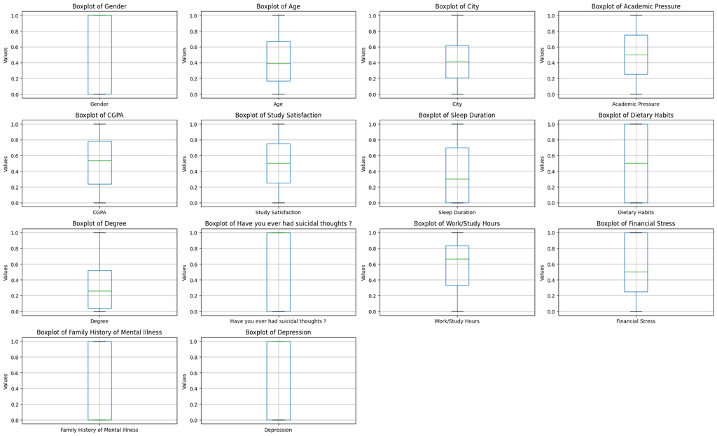

```python
import matplotlib.pyplot as plt

# Get all column names
columns = sampled_df_cleaned.columns

# Initialize the figure
plt.figure(figsize=(20, 15))

# Iterate through all columns and create boxplots
for i, column in enumerate(columns, 1):
    plt.subplot(5, 4, i)  # Create subplots (5 rows x 4 columns, adjust layout based on the number of columns)
    sampled_df_cleaned.boxplot(column=column)
    plt.title(f"Boxplot of {column}")
    plt.ylabel("Values")

# Adjust layout to avoid overlapping
plt.tight_layout()
plt.show()
```

```python
sampled_df_cleaned.head()
```

|  | Gender | Age | City | Academic Pressure | CGPA | Study Satisfaction | Sleep Duration | Dietary Habits | Degree | Have you ever had suicidal thoughts ? | Work/Study Hours | Financial Stress | Family History of Mental Illness | Depression |
| --- | --- | --- | --- | --- | --- | --- | --- | --- | --- | --- | --- | --- | --- | --- |
| 16479 | 0.0 | 0.500000 | 0.000000 | 0.25 | 0.595528 | 1.0 | 0.7 | 0.0 | 0.000000 | 1.0 | 0.416667 | 1.0 | 0.0 | 1.0 |
| 19518 | 1.0 | 0.055556 | 0.029412 | 1.00 | 0.288618 | 0.5 | 1.0 | 0.0 | 0.037037 | 1.0 | 0.750000 | 0.0 | 0.0 | 0.0 |
| 27260 | 1.0 | 0.055556 | 0.058824 | 0.50 | 0.134146 | 0.5 | 0.0 | 0.0 | 0.037037 | 1.0 | 0.166667 | 0.5 | 0.0 | 1.0 |
| 8318 | 0.0 | 0.444444 | 0.088235 | 1.00 | 0.016260 | 0.0 | 0.0 | 0.0 | 0.000000 | 1.0 | 1.000000 | 1.0 | 0.0 | 1.0 |
| 9889 | 1.0 | 0.333333 | 0.117647 | 0.25 | 0.682927 | 0.5 | 1.0 | 0.0 | 0.074074 | 1.0 | 0.916667 | 0.0 | 1.0 | 1.0 |

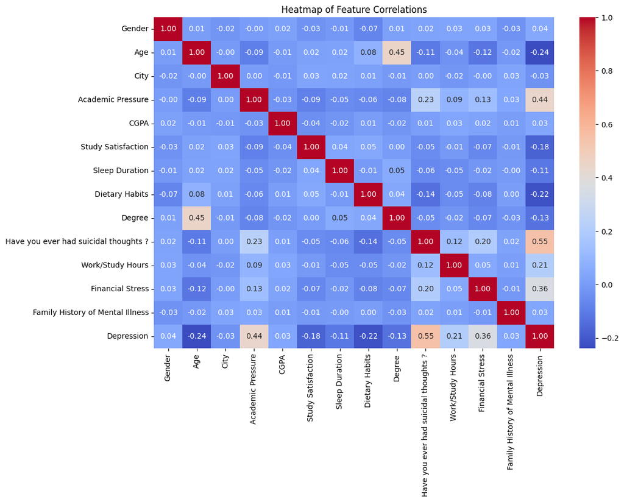

```python
import seaborn as sns
import matplotlib.pyplot as plt

# Calculate the correlation matrix
correlation_matrix = sampled_df_cleaned.corr()

# Plot the heatmap
plt.figure(figsize=(12, 8))
sns.heatmap(correlation_matrix, annot=True, fmt=".2f", cmap="coolwarm", cbar=True)

# Set the title
plt.title("Heatmap of Feature Correlations")
plt.show()
```

### Task and evaluation (10%)

**Guidelines**: Tell us a bit about the main task that in your view this dataset could help solve and propose and justify the evaluation criteria that would be important here, not only considering the task but your exploratory data analysis. For example, if you found that there is class imbalance in the dataset and that the most important class is the minority one, you may want to add costs in your evaluation metric to account for it, or maybe you want to use a metric specifically suited for imbalanced classification.

**[Answer Below]**

**Potential Tasks**

1. Predictive Modeling:

Using the dataset's features, a model can be trained to predict whether a student is likely to suffer from depression. This task involves building classification models to accurately distinguish between depressed and non-depressed students based on the given features. 2. Risk Factor Analysis: Identifying and analyzing the key factors that significantly influence student depression. By examining feature importance, correlation, or weights assigned by models, this task can uncover insights into which aspects (e.g., financial pressure, sleep patterns, academic stress) are most strongly associated with depression risk. 3. Model Comparison for Optimal Performance: Comparing the performance of various machine learning algorithms, such as Random Forest, SVM, Decision Tree, KNN to identify the model that delivers the best predictive accuracy, precision, recall, and overall performance on this dataset. This task helps in selecting the most effective method for future predictive applications.

**Evaluation Method**

1. For task1 "Predictive Modeling", The first step in evaluating the model's performance involved constructing a confusion matrix to analyze the distribution of predictions across true positive, true negative, false positive, and false negative categories. Using this matrix, the overall accuracy was calculated as the proportion of correct predictions out of the total samples. While overall accuracy provides a quick snapshot of the model's performance, it does not adequately reflect its effectiveness when the dataset is imbalanced. In this case, with 1,630 "Depressed" samples and 1,160 "Not Depressed" samples, the imbalance could lead to a misleadingly high accuracy if the model primarily favors the majority class.

To address this limitation, additional metrics were calculated to evaluate the model's performance on each class individually. Precision was used to measure the reliability of the model's predictions for each class, showing the proportion of correct predictions out of all predicted instances for "Depressed" and "Not Depressed." Recall was also examined to understand how well the model identified actual instances of each class, focusing on its ability to capture true cases of "Depressed" and "Not Depressed" students. Finally, the F1 score was calculated to balance precision and recall, providing a single metric that captures the trade-off between the two. By analyzing these class-specific metrics, it became possible to assess whether the model performed consistently across both categories or exhibited bias toward the majority class.

2. For task2 "Risk Factor Analysis", I evaluated the importance of the 13 features (after data cleaning) across multiple models. The goal was to rank the features by their significance in predicting depression and identify the top three most important features for each model. Only qualitative conclusions were drawn, without focusing on specific quantitative values.

For **Random Forest** and **Decision Tree models**, the built-in feature importance scores were used. The higher the importance score, the more critical the feature is for the model's decision-making process.For the **Linear Kernel SVM**, the model does not provide feature importance directly, but its decision boundary is defined by a hyperplane [2]. The hyperplane is represented mathematically by $$w^T \cdot x + b = 0$$ with feature weights W. The feature weights W determining the contribution of each feature to the classification decision. To rank feature importance, I analyzed the absolute values of these weights. Larger absolute weights indicate features with greater influence on the classification outcome. For the **K-NN model**, feature importance was assessed using a feature removal approach. A baseline KNN model was trained with all features, and its accuracy on the test set was recorded. Then, each feature was removed one at a time, and the model was retrained on the reduced dataset to calculate the new test accuracy. The importance of a feature was defined as the difference between the baseline accuracy and the accuracy after the feature's removal. A larger accuracy drop indicated a greater contribution of the feature to the model's performance, providing an indirect but effective way to evaluate feature importance for KNN.

3. For Task 3 "Model Comparison", I used the ROC-AUC metric to compare the performance of different models and identify the best one. ROC-AUC evaluates a model's classification ability by considering its performance across all threshold levels, with the ROC curve plotting the True Positive Rate (TPR) against the False Positive Rate (FPR) [8]. The AUC, representing the area under the ROC curve, quantifies the model's overall discriminative power, with values closer to 1 indicating better performance. Since ROC-AUC is unaffected by class imbalance, it provides a reliable measure of model performance even with the dataset's uneven class distribution (Depressed: Not Depressed = 6:4), making it ideal for this comparison.

### Design and build an ML system (20%)

**Guidelines**: Taking into account the task and evaluation criteria set in the previous section design and build now an ML system. If you go for supervised learning, you could start by partiting your dataset in train and test here and try a model on the dataset. But please justify your choices in each case. Why did you choose a specific ML model? Why is it relevant for the task and dataset at hand? Do you envision any challenges with the use of such model?

Again, we do not ask for a specific model to be used. Instead, we will evaluate the depth and appropriatedness of your analysis. As this section (and some of the following ones) are more open ended we do not specify marks for each question.

Please note that if the dataset of your choice is too large to work with, you can simply choose a subset of it. We will not substract any marks for doing so.

**Answer Below**

**Dataset Split and Model Selection**

For the tasks, evaluation metrics, and dataset described, I chose supervised learning, with the binary target variable indicating whether a student is depressed. The cleaned and preprocessed dataset (2,786 rows) was split into 70% for the training set and 30% for the testing set. The selected models included Decision Tree, Random Forest, SVM, and KNN.

```python
import numpy as np
import pandas as pd
import matplotlib.pyplot as plt
import seaborn as sns
from sklearn.model_selection import train_test_split
from sklearn.ensemble import RandomForestClassifier
from sklearn.metrics import accuracy_score, precision_score, recall_score, f1_score, roc_auc_score, roc_curve
from sklearn.metrics import confusion_matrix, classification_report

# Randomforest
y = sampled_df_cleaned['Depression']  # Target variable
X = sampled_df_cleaned.drop(columns=['Depression'])  # Features

# Split the data into training and testing sets
X_train, X_test, y_train, y_test = train_test_split(X, y, test_size=0.3, random_state=42, shuffle=True)
y_train = y_train.astype(int)
```

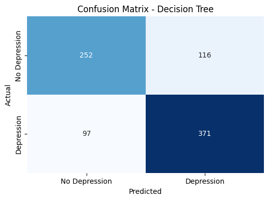

```
Evaluation Metrics - Decision Tree:
Total Accuracy: 0.75
Class 0 (No Depression) - Precision: 0.72, Recall: 0.68, F1 Score: 0.70
Class 1 (Depression) - Precision: 0.76, Recall: 0.79, F1 Score: 0.78

Feature Importances (sorted) - Decision Tree:
                                  Feature  Importance
9   Have you ever had suicidal thoughts ?    0.304601
3                       Academic Pressure    0.123895
11                       Financial Stress    0.087970
2                                    City    0.086646
4                                    CGPA    0.075422
10                       Work/Study Hours    0.072073
1                                     Age    0.061680
8                                  Degree    0.059520
5                      Study Satisfaction    0.039172
7                          Dietary Habits    0.034466
6                          Sleep Duration    0.030286
0                                  Gender    0.014417
12       Family History of Mental Illness    0.009853
```

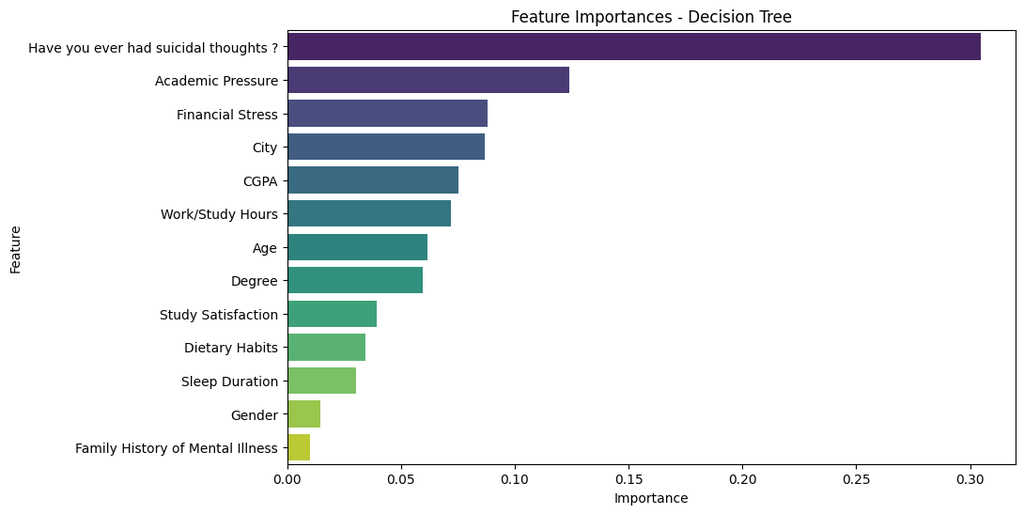

```
ROC-AUC Score - Decision Tree: 0.74
```

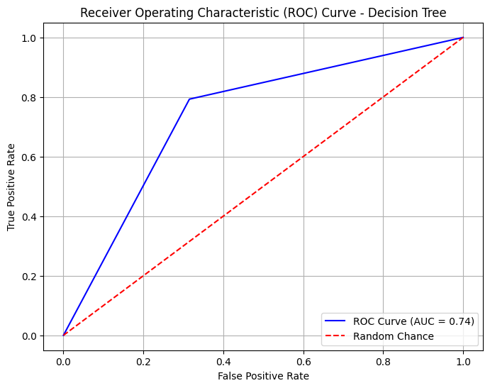

```python
from sklearn.tree import DecisionTreeClassifier

# Decision Tree classifier
max_depth_dt = None  # You can adjust the maximum depth of the tree
decision_tree = DecisionTreeClassifier(max_depth=max_depth_dt, random_state=42)
decision_tree.fit(X_train, y_train)

# Make predictions on the test set
y_pred_dt = decision_tree.predict(X_test)
y_test_dt = y_test.astype(int)
y_pred_dt = y_pred_dt.astype(int)

# Confusion matrix
cm_dt = confusion_matrix(y_test_dt, y_pred_dt)
plt.figure(figsize=(6, 4))
sns.heatmap(cm_dt, annot=True, fmt='d', cmap='Blues', cbar=False, xticklabels=['No Depression', 'Depression'], yticklabels=['No Depression', 'Depression'])
plt.title('Confusion Matrix - Decision Tree')
plt.xlabel('Predicted')
plt.ylabel('Actual')
plt.show()

# Total Accuracy
total_accuracy_dt = accuracy_score(y_test_dt, y_pred_dt)

# Class-wise Metrics
class0_precision_dt = cm_dt[0, 0] / (cm_dt[0, 0] + cm_dt[1, 0])  # TN / (TN + FN)
class0_recall_dt = cm_dt[0, 0] / (cm_dt[0, 0] + cm_dt[0, 1])     # TN / (TN + FP)
class0_f1_dt = 2 * (class0_precision_dt * class0_recall_dt) / (class0_precision_dt + class0_recall_dt)

class1_precision_dt = cm_dt[1, 1] / (cm_dt[1, 1] + cm_dt[0, 1])  # TP / (TP + FP)
class1_recall_dt = cm_dt[1, 1] / (cm_dt[1, 1] + cm_dt[1, 0])     # TP / (TP + FN)
class1_f1_dt = 2 * (class1_precision_dt * class1_recall_dt) / (class1_precision_dt + class1_recall_dt)

# Print metrics
print("\nEvaluation Metrics - Decision Tree:")
print(f"Total Accuracy: {total_accuracy_dt:.2f}")
print(f"Class 0 (No Depression) - Precision: {class0_precision_dt:.2f}, Recall: {class0_recall_dt:.2f}, F1 Score: {class0_f1_dt:.2f}")
print(f"Class 1 (Depression) - Precision: {class1_precision_dt:.2f}, Recall: {class1_recall_dt:.2f}, F1 Score: {class1_f1_dt:.2f}")

# Feature Importances
feature_importances_dt = decision_tree.feature_importances_
feature_names_dt = X.columns
importance_df_dt = pd.DataFrame({'Feature': feature_names_dt, 'Importance': feature_importances_dt})
importance_df_dt = importance_df_dt.sort_values(by='Importance', ascending=False)  # Sort by importance

print("\nFeature Importances (sorted) - Decision Tree:")
print(importance_df_dt)

# Plot Feature Importances
plt.figure(figsize=(10, 6))
sns.barplot(x=importance_df_dt['Importance'], y=importance_df_dt['Feature'], palette="viridis")
plt.title("Feature Importances - Decision Tree")
plt.xlabel("Importance")
plt.ylabel("Feature")
plt.show()

# ROC Curve and AUC
roc_auc_dt = roc_auc_score(y_test_dt, decision_tree.predict_proba(X_test)[:, 1])
fpr_dt, tpr_dt, thresholds_dt = roc_curve(y_test_dt, decision_tree.predict_proba(X_test)[:, 1])

print(f"\nROC-AUC Score - Decision Tree: {roc_auc_dt:.2f}")

plt.figure(figsize=(8, 6))
plt.plot(fpr_dt, tpr_dt, label=f"ROC Curve (AUC = {roc_auc_dt:.2f})", color='blue')
plt.plot([0, 1], [0, 1], 'r--', label='Random Chance')
plt.title('Receiver Operating Characteristic (ROC) Curve - Decision Tree')
plt.xlabel('False Positive Rate')
plt.ylabel('True Positive Rate')
plt.legend(loc='lower right')
plt.grid()
plt.show()
```

**Random Forest** is an ensemble learning method based on Decision Trees that improves model performance by constructing multiple decision trees and aggregating their predictions. For classification tasks, the model determines the final output by majority voting among the trees, while for regression tasks, it computes the average of their predictions [6]. Since Random Forest is an extension of Decision Trees, it aligns well with datasets and tasks suitable for Decision Tree models. This suggests that Random Forest should perform even better in such scenarios. Furthermore, Random Forest also provides built-in feature importance analysis, making it a valuable tool for identifying key risk factors contributing to depression.

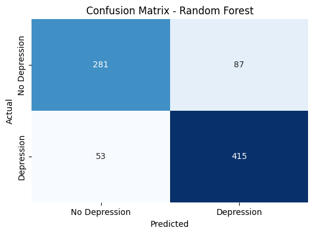

```
Evaluation Metrics - Random Forest:
Total Accuracy: 0.83
Class 0 (No Depression) - Precision: 0.84, Recall: 0.76, F1 Score: 0.80
Class 1 (Depression) - Precision: 0.83, Recall: 0.89, F1 Score: 0.86

Feature Importances (sorted) - Random Forest:
                                  Feature  Importance
9   Have you ever had suicidal thoughts ?    0.205885
3                       Academic Pressure    0.153923
11                       Financial Stress    0.095691
1                                     Age    0.081438
10                       Work/Study Hours    0.081185
4                                    CGPA    0.076962
2                                    City    0.069165
8                                  Degree    0.067934
5                      Study Satisfaction    0.051311
7                          Dietary Habits    0.042685
6                          Sleep Duration    0.041451
0                                  Gender    0.016276
12       Family History of Mental Illness    0.016094
```

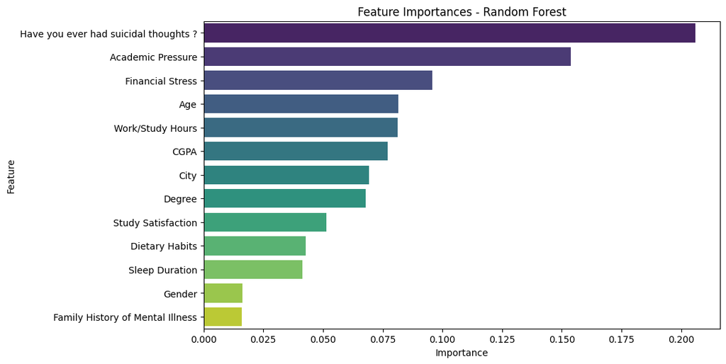

```
ROC-AUC Score - Random Forest: 0.90
```

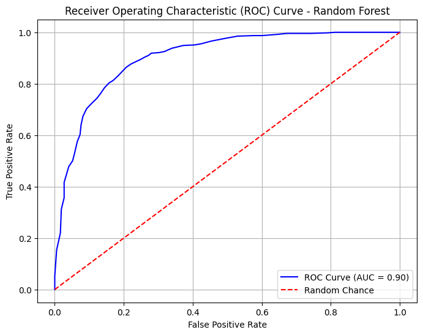

```python
# Random Forest classifier
n_estimators_rf = 50  # You can adjust the number of trees (n_estimators) as needed
random_forest_rf = RandomForestClassifier(n_estimators=n_estimators_rf, random_state=42)
random_forest_rf.fit(X_train, y_train)

# Make predictions on the test set
y_pred_rf = random_forest_rf.predict(X_test)
y_test_rf = y_test.astype(int)
y_pred_rf = y_pred_rf.astype(int)

# Confusion matrix
cm_rf = confusion_matrix(y_test_rf, y_pred_rf)
plt.figure(figsize=(6, 4))
sns.heatmap(cm_rf, annot=True, fmt='d', cmap='Blues', cbar=False, xticklabels=['No Depression', 'Depression'], yticklabels=['No Depression', 'Depression'])
plt.title('Confusion Matrix - Random Forest')
plt.xlabel('Predicted')
plt.ylabel('Actual')
plt.show()

# Total Accuracy
total_accuracy_rf = accuracy_score(y_test_rf, y_pred_rf)

# Class-wise Metrics
class0_precision_rf = cm_rf[0, 0] / (cm_rf[0, 0] + cm_rf[1, 0])  # TN / (TN + FN)
class0_recall_rf = cm_rf[0, 0] / (cm_rf[0, 0] + cm_rf[0, 1])     # TN / (TN + FP)
class0_f1_rf = 2 * (class0_precision_rf * class0_recall_rf) / (class0_precision_rf + class0_recall_rf)

class1_precision_rf = cm_rf[1, 1] / (cm_rf[1, 1] + cm_rf[0, 1])  # TP / (TP + FP)
class1_recall_rf = cm_rf[1, 1] / (cm_rf[1, 1] + cm_rf[1, 0])     # TP / (TP + FN)
class1_f1_rf = 2 * (class1_precision_rf * class1_recall_rf) / (class1_precision_rf + class1_recall_rf)

# Print metrics
print("\nEvaluation Metrics - Random Forest:")
print(f"Total Accuracy: {total_accuracy_rf:.2f}")
print(f"Class 0 (No Depression) - Precision: {class0_precision_rf:.2f}, Recall: {class0_recall_rf:.2f}, F1 Score: {class0_f1_rf:.2f}")
print(f"Class 1 (Depression) - Precision: {class1_precision_rf:.2f}, Recall: {class1_recall_rf:.2f}, F1 Score: {class1_f1_rf:.2f}")

# Feature Importances
feature_importances_rf = random_forest_rf.feature_importances_
feature_names_rf = X.columns
importance_df_rf = pd.DataFrame({'Feature': feature_names_rf, 'Importance': feature_importances_rf})
importance_df_rf = importance_df_rf.sort_values(by='Importance', ascending=False)  # Sort by importance

print("\nFeature Importances (sorted) - Random Forest:")
print(importance_df_rf)

# Plot Feature Importances
plt.figure(figsize=(10, 6))
sns.barplot(x=importance_df_rf['Importance'], y=importance_df_rf['Feature'], palette="viridis")
plt.title("Feature Importances - Random Forest")
plt.xlabel("Importance")
plt.ylabel("Feature")
plt.show()

# ROC Curve and AUC
roc_auc_rf = roc_auc_score(y_test_rf, random_forest_rf.predict_proba(X_test)[:, 1])
fpr_rf, tpr_rf, thresholds_rf = roc_curve(y_test_rf, random_forest_rf.predict_proba(X_test)[:, 1])

print(f"\nROC-AUC Score - Random Forest: {roc_auc_rf:.2f}")

plt.figure(figsize=(8, 6))
plt.plot(fpr_rf, tpr_rf, label=f"ROC Curve (AUC = {roc_auc_rf:.2f})", color='blue')
plt.plot([0, 1], [0, 1], 'r--', label='Random Chance')
plt.title('Receiver Operating Characteristic (ROC) Curve - Random Forest')
plt.xlabel('False Positive Rate')
plt.ylabel('True Positive Rate')
plt.legend(loc='lower right')
plt.grid()
plt.show()
```

For the **SVM** model, I primarily used a Linear SVM for modeling. Linear SVM assumes that the data can be separated using a linear decision boundary [1]. Since determining whether a student is depressed is a binary classification problem, the linear decision boundary provided by Linear SVM aligns well with the task of predicting depression based on multiple features. Additionally, as mentioned earlier, the hyperplane equation allows the computation of the weight vector ( W ), which represents the importance of each feature in the classification task. This makes Linear SVM not only effective for prediction but also valuable for analyzing feature importance.

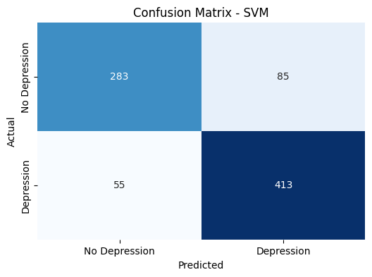

```
Evaluation Metrics - SVM:
Total Accuracy: 0.83
Class 0 (No Depression) - Precision: 0.84, Recall: 0.77, F1 Score: 0.80
Class 1 (Depression) - Precision: 0.83, Recall: 0.88, F1 Score: 0.86

Feature Importances (sorted) - SVM:
                                  Feature  Importance
3                       Academic Pressure    2.181606
9   Have you ever had suicidal thoughts ?    1.810734
11                       Financial Stress    1.444325
1                                     Age    1.043395
10                       Work/Study Hours    0.963664
5                      Study Satisfaction    0.903007
7                          Dietary Habits    0.782741
6                          Sleep Duration    0.447350
8                                  Degree    0.352020
2                                    City    0.270883
12       Family History of Mental Illness    0.138939
4                                    CGPA    0.069440
0                                  Gender    0.047045
```

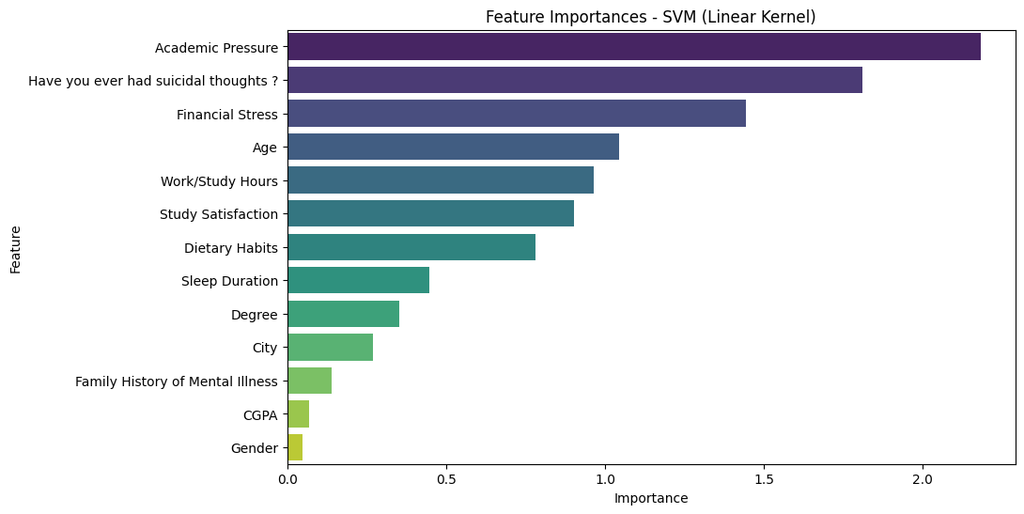

```
ROC-AUC Score - SVM: 0.91
```

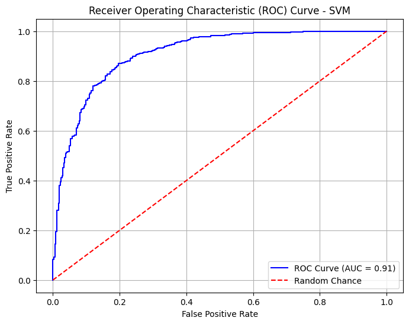

```python
from sklearn.svm import SVC

# SVM classifier
kernel_svm = 'linear'  # You can adjust the kernel ('linear', 'poly', 'rbf', 'sigmoid') as needed
C_svm = 1.0  # Regularization parameter
svm_model = SVC(kernel=kernel_svm, C=C_svm, probability=True, random_state=42)
svm_model.fit(X_train, y_train)

# Make predictions on the test set
y_pred_svm = svm_model.predict(X_test)
y_test_svm = y_test.astype(int)
y_pred_svm = y_pred_svm.astype(int)

# Confusion matrix
cm_svm = confusion_matrix(y_test_svm, y_pred_svm)
plt.figure(figsize=(6, 4))
sns.heatmap(cm_svm, annot=True, fmt='d', cmap='Blues', cbar=False, xticklabels=['No Depression', 'Depression'], yticklabels=['No Depression', 'Depression'])
plt.title('Confusion Matrix - SVM')
plt.xlabel('Predicted')
plt.ylabel('Actual')
plt.show()

# Total Accuracy
total_accuracy_svm = accuracy_score(y_test_svm, y_pred_svm)

# Class-wise Metrics
class0_precision_svm = cm_svm[0, 0] / (cm_svm[0, 0] + cm_svm[1, 0])  # TN / (TN + FN)
class0_recall_svm = cm_svm[0, 0] / (cm_svm[0, 0] + cm_svm[0, 1])     # TN / (TN + FP)
class0_f1_svm = 2 * (class0_precision_svm * class0_recall_svm) / (class0_precision_svm + class0_recall_svm)

class1_precision_svm = cm_svm[1, 1] / (cm_svm[1, 1] + cm_svm[0, 1])  # TP / (TP + FP)
class1_recall_svm = cm_svm[1, 1] / (cm_svm[1, 1] + cm_svm[1, 0])     # TP / (TP + FN)
class1_f1_svm = 2 * (class1_precision_svm * class1_recall_svm) / (class1_precision_svm + class1_recall_svm)

# Print metrics
print("\nEvaluation Metrics - SVM:")
print(f"Total Accuracy: {total_accuracy_svm:.2f}")
print(f"Class 0 (No Depression) - Precision: {class0_precision_svm:.2f}, Recall: {class0_recall_svm:.2f}, F1 Score: {class0_f1_svm:.2f}")
print(f"Class 1 (Depression) - Precision: {class1_precision_svm:.2f}, Recall: {class1_recall_svm:.2f}, F1 Score: {class1_f1_svm:.2f}")

# Extract feature importance for linear SVM
feature_importances_svm = np.abs(svm_model.coef_).flatten()  # Absolute value of coefficients
feature_names_svm = X.columns

# Create a DataFrame for feature importance
importance_df_svm = pd.DataFrame({
    'Feature': feature_names_svm,
    'Importance': feature_importances_svm
}).sort_values(by='Importance', ascending=False)

# Print feature importance
print("\nFeature Importances (sorted) - SVM:")
print(importance_df_svm)

# Plot feature importance
plt.figure(figsize=(10, 6))
sns.barplot(x=importance_df_svm['Importance'], y=importance_df_svm['Feature'], palette="viridis")
plt.title("Feature Importances - SVM (Linear Kernel)")
plt.xlabel("Importance")
plt.ylabel("Feature")
plt.show()


# ROC Curve and AUC
roc_auc_svm = roc_auc_score(y_test_svm, svm_model.decision_function(X_test))
fpr_svm, tpr_svm, thresholds_svm = roc_curve(y_test_svm, svm_model.decision_function(X_test))

print(f"\nROC-AUC Score - SVM: {roc_auc_svm:.2f}")

plt.figure(figsize=(8, 6))
plt.plot(fpr_svm, tpr_svm, label=f"ROC Curve (AUC = {roc_auc_svm:.2f})", color='blue')
plt.plot([0, 1], [0, 1], 'r--', label='Random Chance')
plt.title('Receiver Operating Characteristic (ROC) Curve - SVM')
plt.xlabel('False Positive Rate')
plt.ylabel('True Positive Rate')
plt.legend(loc='lower right')
plt.grid()
plt.show()
```

The **K-NN** model classifies or predicts by calculating the distance between a new sample and the samples in the training data, identifying the ( K ) nearest neighbors, and using their categories to make decisions [5]. This approach is particularly suited for the binary classification task of determining whether a student is depressed based on multiple features. After training the K-NN model, depressed students may form distinct clustering patterns in the feature space, which the model leverages to predict and classify test samples. Although K-NN does not provide direct methods for feature importance analysis, importance can be indirectly assessed by comparing the baseline model's accuracy with the accuracy of a model trained after removing a specific feature, identifying the contribution of that feature to the model's performance.

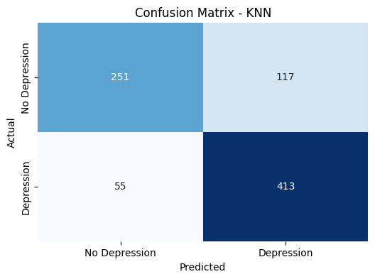

```
Evaluation Metrics - KNN:
Total Accuracy: 0.79
Class 0 (No Depression) - Precision: 0.82, Recall: 0.68, F1 Score: 0.74
Class 1 (Depression) - Precision: 0.78, Recall: 0.88, F1 Score: 0.83

Feature Importances (sorted) - KNN:
                                  Feature  Importance
9   Have you ever had suicidal thoughts ?    0.093301
3                       Academic Pressure    0.037081
11                       Financial Stress    0.022727
0                                  Gender    0.019139
7                          Dietary Habits    0.016746
4                                    CGPA    0.015550
1                                     Age    0.014354
5                      Study Satisfaction    0.011962
2                                    City    0.010766
12       Family History of Mental Illness    0.008373
6                          Sleep Duration    0.003589
10                       Work/Study Hours    0.000000
8                                  Degree   -0.001196
```

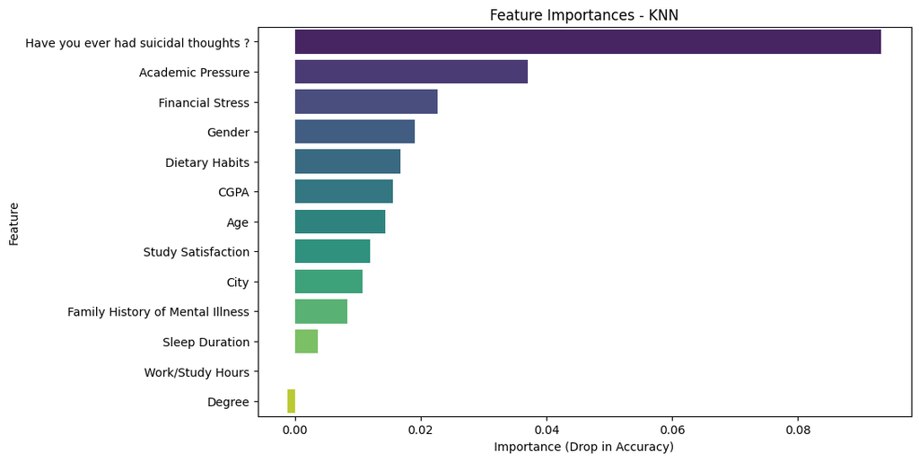

```
ROC-AUC Score - KNN: 0.84
```

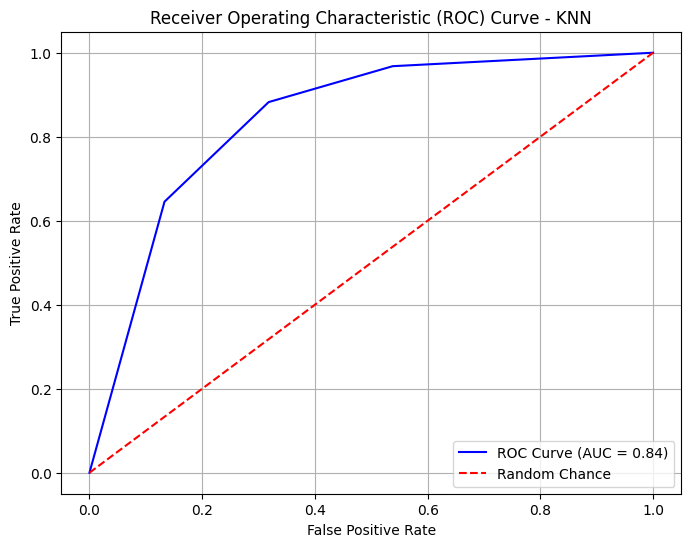

```python
from sklearn.neighbors import KNeighborsClassifier
from sklearn.metrics import accuracy_score

# KNN classifier
n_neighbors_knn = 3  # Number of neighbors (you can adjust as needed)
knn_model = KNeighborsClassifier(n_neighbors=n_neighbors_knn)
knn_model.fit(X_train, y_train)

# Make predictions on the test set
y_pred_knn = knn_model.predict(X_test)
y_test_knn = y_test.astype(int)
y_pred_knn = y_pred_knn.astype(int)

# Confusion matrix
cm_knn = confusion_matrix(y_test_knn, y_pred_knn)
plt.figure(figsize=(6, 4))
sns.heatmap(cm_knn, annot=True, fmt='d', cmap='Blues', cbar=False, xticklabels=['No Depression', 'Depression'], yticklabels=['No Depression', 'Depression'])
plt.title('Confusion Matrix - KNN')
plt.xlabel('Predicted')
plt.ylabel('Actual')
plt.show()

# Total Accuracy
total_accuracy_knn = accuracy_score(y_test_knn, y_pred_knn)

# Class-wise Metrics
class0_precision_knn = cm_knn[0, 0] / (cm_knn[0, 0] + cm_knn[1, 0])  # TN / (TN + FN)
class0_recall_knn = cm_knn[0, 0] / (cm_knn[0, 0] + cm_knn[0, 1])     # TN / (TN + FP)
class0_f1_knn = 2 * (class0_precision_knn * class0_recall_knn) / (class0_precision_knn + class0_recall_knn)

class1_precision_knn = cm_knn[1, 1] / (cm_knn[1, 1] + cm_knn[0, 1])  # TP / (TP + FP)
class1_recall_knn = cm_knn[1, 1] / (cm_knn[1, 1] + cm_knn[1, 0])     # TP / (TP + FN)
class1_f1_knn = 2 * (class1_precision_knn * class1_recall_knn) / (class1_precision_knn + class1_recall_knn)

# Print metrics
print("\nEvaluation Metrics - KNN:")
print(f"Total Accuracy: {total_accuracy_knn:.2f}")
print(f"Class 0 (No Depression) - Precision: {class0_precision_knn:.2f}, Recall: {class0_recall_knn:.2f}, F1 Score: {class0_f1_knn:.2f}")
print(f"Class 1 (Depression) - Precision: {class1_precision_knn:.2f}, Recall: {class1_recall_knn:.2f}, F1 Score: {class1_f1_knn:.2f}")

# Initialize a DataFrame to store feature importance
feature_importance_knn = []

# Baseline accuracy
baseline_accuracy = accuracy_score(y_test_knn, knn_model.predict(X_test))

# Evaluate importance by removing each feature
for feature in X.columns:
    X_train_reduced = X_train.drop(columns=[feature])
    X_test_reduced = X_test.drop(columns=[feature])

    # Train and evaluate a new KNN model
    knn_model_reduced = KNeighborsClassifier(n_neighbors=n_neighbors_knn)
    knn_model_reduced.fit(X_train_reduced, y_train)
    reduced_accuracy = accuracy_score(y_test_knn, knn_model_reduced.predict(X_test_reduced))

    # Importance as the drop in accuracy
    importance = baseline_accuracy - reduced_accuracy
    feature_importance_knn.append({'Feature': feature, 'Importance': importance})

# Convert to DataFrame and sort by importance
importance_df_knn = pd.DataFrame(feature_importance_knn).sort_values(by='Importance', ascending=False)

# Print feature importance
print("\nFeature Importances (sorted) - KNN:")
print(importance_df_knn)

# Plot feature importance
plt.figure(figsize=(10, 6))
sns.barplot(x=importance_df_knn['Importance'], y=importance_df_knn['Feature'], palette="viridis")
plt.title("Feature Importances - KNN")
plt.xlabel("Importance (Drop in Accuracy)")
plt.ylabel("Feature")
plt.show()


# ROC Curve and AUC
roc_auc_knn = roc_auc_score(y_test_knn, knn_model.predict_proba(X_test)[:, 1])
fpr_knn, tpr_knn, thresholds_knn = roc_curve(y_test_knn, knn_model.predict_proba(X_test)[:, 1])

print(f"\nROC-AUC Score - KNN: {roc_auc_knn:.2f}")

plt.figure(figsize=(8, 6))
plt.plot(fpr_knn, tpr_knn, label=f"ROC Curve (AUC = {roc_auc_knn:.2f})", color='blue')
plt.plot([0, 1], [0, 1], 'r--', label='Random Chance')
plt.title('Receiver Operating Characteristic (ROC) Curve - KNN')
plt.xlabel('False Positive Rate')
plt.ylabel('True Positive Rate')
plt.legend(loc='lower right')
plt.grid()
plt.show()
```

**Potential Challenges to Modelling**

Different models have varying requirements for feature standardization, and feeding unprocessed data directly into a model could lead to suboptimal performance or even errors. To prevent such issues, all features were numerical and normalized before being used for model training.

Additionally, hyperparameter tuning is critical to optimizing model performance, as different hyperparameters can significantly affect the results. For instance, the number of decision trees in Random Forest, the choice of kernel function in SVM, and the ( K ) value in KNN all require careful experimentation to identify the optimal settings for the specific dataset and task.This is a very time-consuming and tedious task.

### Experimental analysis (performance & scalability) (20%)

**Guidelines**: Test your model here. You can do hyper-parameter tuning and any ablation studies you consider important. How does your model perform? Is there any room for improvement? If so, what do you think it's needed? Comment as well on how does the model compare to previous baselines (yours or from the literature). Do you think model's performance is enough for the application that you are aiming to address? Is the model scalable to a real-world application? Is training data enough for such an application? How does the model's performance compare to a more/less computationally heavy model? Some of these questions may be more or less relevant depending on your application, so we leave it up to you to decide which factors in terms of performance and scalability you consider most important to evaluate.

[output not shown]

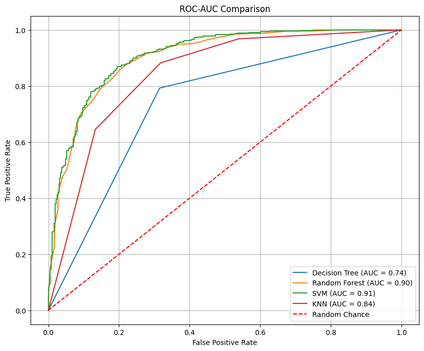

```python
# Assuming the following variables are already defined: total_accuracy_dt, total_accuracy_rf, total_accuracy_svm, total_accuracy_knn

# First table: Model performance metrics, including Total Accuracy
metrics_data = {
    'Metric': ['Total Accuracy',
               'Class 0 Precision', 'Class 0 Recall', 'Class 0 F1',
               'Class 1 Precision', 'Class 1 Recall', 'Class 1 F1'],
    'Decision Tree': [total_accuracy_dt,
                       class0_precision_dt, class0_recall_dt, class0_f1_dt,
                       class1_precision_dt, class1_recall_dt, class1_f1_dt],
    'Random Forest': [total_accuracy_rf,
                       class0_precision_rf, class0_recall_rf, class0_f1_rf,
                       class1_precision_rf, class1_recall_rf, class1_f1_rf],
    'SVM': [total_accuracy_svm,
            class0_precision_svm, class0_recall_svm, class0_f1_svm,
            class1_precision_svm, class1_recall_svm, class1_f1_svm],
    'KNN': [total_accuracy_knn,
            class0_precision_knn, class0_recall_knn, class0_f1_knn,
            class1_precision_knn, class1_recall_knn, class1_f1_knn],
}

metrics_df = pd.DataFrame(metrics_data)
print("Model Performance Metrics:")
print(metrics_df)

# Second table: Top 3 important features for each model
importance_data = {
    'Dimension': ['Dimension 1', 'Dimension 2', 'Dimension 3'],
    'Decision Tree': importance_df_dt['Feature'][:3].values,
    'Random Forest': importance_df_rf['Feature'][:3].values,
    'SVM': importance_df_svm['Feature'][:3].values,
    'KNN': importance_df_knn['Feature'][:3].values,
}

importance_df = pd.DataFrame(importance_data)
print("Top 3 Important Features for Each Model:")
print(importance_df)

# Third figure: ROC-AUC curve comparison
plt.figure(figsize=(10, 8))
plt.plot(fpr_dt, tpr_dt, label=f"Decision Tree (AUC = {roc_auc_dt:.2f})")
plt.plot(fpr_rf, tpr_rf, label=f"Random Forest (AUC = {roc_auc_rf:.2f})")
plt.plot(fpr_svm, tpr_svm, label=f"SVM (AUC = {roc_auc_svm:.2f})")
plt.plot(fpr_knn, tpr_knn, label=f"KNN (AUC = {roc_auc_knn:.2f})")
plt.plot([0, 1], [0, 1], 'r--', label='Random Chance')
plt.title('ROC-AUC Comparison')
plt.xlabel('False Positive Rate')
plt.ylabel('True Positive Rate')
plt.legend(loc='lower right')
plt.grid()
plt.show()
```

**Hyperparamater Tuning**

Since the focus of this experiment was not on extensive optimization of any single model, hyperparameters were selected through manual tuning. Below is a brief overview of the hyperparameter choices for each model:

For the Decision Tree model, I did not impose a maximum depth restriction, allowing the tree to split nodes as deeply as possible until the data could no longer be further divided.

For the Random Forest model, I adjusted the number of decision trees to control the forest size. Through observation, the model performed relatively best when the number of trees was set to 50.

For the SVM model, the `kernel` parameter, which determines how the model handles the shape of the data separation, was set to `linear`. This choice yielded the relatively best performance in the current scenario.

For the KNN model, classification is determined by the majority vote of the ( K ) nearest neighbors. In this case, the model achieved relatively optimal performance when ( K ) was set to 3.

**Model Performance**

When I conducted my analysis and modeling, there were no available baselines or code on Kaggle for this dataset. Therefore, my primary objective was to analyze and compare the performance of Decision Tree, Random Forest, SVM, and KNN models on this dataset, potentially providing a baseline for future work on similar tasks.

From the perspective of overall accuracy, Random Forest and SVM performed equally well, both achieving 83% accuracy. Decision Tree had the lowest accuracy at 74%. However, given the class imbalance in the target variable, with different numbers of samples for "Depressed" and "Not Depressed," I also examined class-specific metrics such as precision, recall, and F1 for each label.

- Class 0 Precision measures the proportion of predicted "Not Depressed" samples that are actually "Not Depressed."
- Class 0 Recall measures the proportion of actual "Not Depressed" samples correctly predicted as "Not Depressed."
- Class 1 Precision measures the proportion of predicted "Depressed" samples that are actually "Depressed."
- Class 1 Recall measures the proportion of actual "Depressed" samples correctly predicted as "Depressed."

For this task—predicting whether a student is depressed based on multiple features—Class 1 (Depressed) is the critical class. It is essential not to misclassify actually depressed students as non-depressed, so Class 1 Recall and Class 0 Precision are key metrics.

For Class 0 Precision, the ranking was: Random Forest > SVM > KNN > Decision Tree. For Class 1 Recall, the ranking was: Random Forest > SVM = KNN > Dscision Tree.

Given these results, Random Forest demonstrated the best performance overall for this dataset and task. However, the difference between Random Forest and SVM was minimal, making their performance essentially equivalent. In practical applications, both Random Forest and SVM achieved an overall accuracy of approximately 83%, with Class 0 Precision around 84% and Class 1 Recall approximately 88%. Further optimization of both the models and the dataset would be required for broader real-world applications.

From the feature importance rankings across models, the top three factors influencing student depression were consistently: "Have you ever had suicidal thoughts?", "Academic Pressure," and "Financial Stress." These results suggest that schools, institutions, or support personnel should focus on these areas to better assess depression and mitigate its risks among students.

To evaluate model performance under different thresholds, ROC-AUC was used. The ranking was: SVM > Random Forest > KNN > Decision Tree. Although SVM slightly outperformed Random Forest, with a 0.01 higher AUC, Random Forest still achieved an AUC of 0.90, while KNN and Decision Tree had AUCs of 0.84 and 0.74, respectively. Based on these results, SVM and Random Forest demonstrated equally strong classification performance across thresholds.

**Improvement Suggestion**

To improve the performance of different models under the current conditions, a systematic approach can be employed by setting up a loop to test the models with various hyperparameter combinations. By evaluating the performance under each configuration, the optimal hyperparameters can be identified and saved for each model. For example, for Random Forest, testing different numbers of trees can help determine the ideal forest size, while cross-validation can be used to identify the best ( K ) value for the KNN model.

Due to time and resource constraints, I used pre-trained machine learning models. However, for specific tasks and requirements, performance can be further enhanced by building custom machine learning frameworks tailored to the dataset and problem. This approach would allow for greater flexibility in optimizing the models and aligning them with task-specific goals.

### Ethical considerations (15%)

**Guidelines**: Analyse and discuss the ethical dimensions of the application: bias, fairness, interpretability, etc. Some of these may not be relevant, but we leave this for you to decide which ones would be the relevant ones to consider for the problem at hand. Here you could do a sensitivity/interpretability analysis of the model, to study the effect of different variables or examine whether there are any biases (e.g. the model performs best for certain group of examples in your dataset). You could also link this part with your exploratory data analysis, focusing on the ethical dimensions of the dataset rather than the model you built. Justify what your analysis tell us about these ethical dimensions.

**Answer Below**

**Data bias and fairness:** From a geographical perspective, the dataset predominantly represents data from India, leading to potential overfitting of the models to India's cultural, socioeconomic background, and education system. This limitation hinders the generalizability of the models to other countries or regions. For instance, student mental health issues in India might be influenced by unique social pressures such as intense educational competition, familial responsibilities, and cultural or religious expectations. These factors might not apply in the same way to students in other developed or developing countries, potentially causing models trained on this dataset to exhibit bias and unfairness when applied to other populations.

**Privacy and ethics:** The dataset includes 18 dimensions of personal information, such as age, gender, and academic performance, which are sensitive and relate to individuals' privacy. When analyzing and utilizing the data, it is critical to ensure that participants were explicitly informed about the use of their data for machine learning and research purposes and were aware of potential risks and applications. While the dataset has been anonymized, it lacks advanced encryption measures. Specific combinations of attributes (e.g., age, gender, and city) could potentially re-identify individuals through cross-referencing. Therefore, data collection should clearly communicate the purpose and risks to participants, and de-identification measures must be implemented to protect their privacy.

**Data quality** The data was collected primarily through self-reported surveys completed by students, introducing the risk of inaccurate or inconsistent responses. Some students might not have answered truthfully, either due to carelessness or intentional misrepresentation to conceal sensitive information. Others might provide socially desirable answers, resulting in bias. This decreases the credibility of the dataset and may lead to missing data (e.g., missing economic stress information) or outliers that do not reflect true mental health states. Such issues can complicate data preprocessing and compromise the predictive accuracy of the models.

### Sustainable development relevance & impact (15%)

**Guidelines**: Discuss what are the current challenges surrounding this dataset in terms of sustainable development and how can ML help overcome them? Additionally, bring out all of the things you have managed to do and understand from the experiments and connect them to sustainable development. Discuss what are the challenges of deploying such a model and how it could impact our progress towards achieving the sustainable development goals.

**Answer Below**

**Current Challenges of Dataset and How Can ML Help**

In the previous section, we highlighted ethical and sustainability challenges, which can be addressed or even resolved using machine learning techniques. For instance, privacy and ethical concerns related to datasets can be mitigated through a distributed machine learning approach known as federated learning [9]. This method enables training models directly on user devices or local data without requiring the data to leave its source. By doing so, federated learning ensures privacy protection while facilitating effective model training. Models trained using this approach can serve as a robust technical foundation for applications—such as those predicting depression based on multiple dimensions—and provide a promising direction for future improvements.

**Connection between SDGs and ML application**

**SDG 3: Ensure healthy lives and promote well-being for all at all ages**

- **SDG 3.4: Reducing suicide mortality through the promotion of mental health:** Depression is one of the most impactful psychological conditions among non-communicable diseases, significantly affecting individuals' health and well-being. By predicting whether students are at risk of depression and identifying key influencing factors, targeted interventions can be designed to help reduce suicide mortality caused by mental health issues.

**SDG 4: Ensure inclusive and equitable quality education and promote lifelong learning opportunities for all**

- **SDG 4.3: Equal access to quality technical, vocational, and higher education & SDG 4.a: Create inclusive and safe learning environments:**Depression has a significant impact on students' learning abilities and academic completion rates, undermining educational equity and quality. Its prevalence may be linked to factors such as campus culture, academic pressure, or lack of social support. Analyzing the importance of different dimensions influencing depression can help schools and related institutions understand these factors and provide targeted support to improve educational outcomes and inclusivity.

**SDG 8: Promote sustained, inclusive, and sustainable economic growth, full and productive employment, and decent work for all**

- **SDG 8.6: Reduce the number of youth not in education, employment, or training:** By using predictive models to identify students at risk of depression early, targeted support can be provided to help them complete their education. This reduces the likelihood of dropout due to depression, ultimately addressing societal issues related to disengaged youth and facilitating their integration into the workforce.

**SDG 10: Reduce inequality within and among countries**

- **SDG 10.2: Promote social inclusion:**By exploring factors influencing student depression and raising public awareness, societal attention toward individuals with depression can be enhanced. Promoting social inclusion and understanding can help reduce stigma, improve recovery outcomes, and strengthen the social integration of individuals experiencing depression.

**SDG 16: Promote peaceful and inclusive societies for sustainable development, provide access to justice for all, and build effective, accountable, and inclusive institutions at all levels**

- **SDG 16.1 & 16.2: Reduce campus violence and psychological abuse:** The analysis of factors contributing to depression may reveal correlations with campus violence, gender discrimination, or psychological abuse. Early identification of such external influences can offer insights to school administrators, enabling them to reduce violence and create a more harmonious campus environment that mitigates potential mental health triggers.

**SDG 17: Strengthen the means of implementation and revitalize the global partnership for sustainable development**

- **SDG 17.18: Provide high-quality, disaggregated data to support policy-making:** This task focuses on predicting student depression and identifying related factors, providing the education sector with disaggregated data (e.g., by age, gender, and education level). Such data and insights can form the foundation for designing effective interventions at the school level while also supporting national policies or international collaboration in addressing mental health issues.

**Challenges with The Applicatioin**

**SDG 16.1 & 16.2:** In the previous section, I noted that this application can assist schools or relevant institutions in identifying potential factors contributing to depression. It can also provide guidance for reducing incidents of campus violence and fostering a harmonious campus environment, thereby mitigating potential triggers of mental health issues. However, it is crucial to recognize that the misuse of depression model results could lead to the stigmatization or labeling of students identified as being at risk for depression, particularly in the absence of professional support and proper guidance. Such labeling might expose students to discrimination or social exclusion, exacerbating their mental health challenges and creating negative social dynamics within the campus environment.

This risk may also undermine students' trust in schools, institutions, and mental health services, making them less willing to seek help proactively and delaying timely interventions. Over time, this not only impacts the academic and social lives of individuals but also negatively affects the overall mental health climate and inclusivity of the campus. This could further contribute to the proliferation and accumulation of mental health issues within the student population.

**SDG10.3 Promoting equality and eliminating discrimination & SDG17.8 Supporting Least Developed Countries in building science, technology and innovation mechanisms:** Firstly, the data required for depression prediction models may be challenging to collect in remote or developing regions due to resource limitations. These areas often lack comprehensive mental health records, educational data, and infrastructure support. Additionally, outdated technological facilities, low internet penetration rates, and a shortage of skilled data science professionals pose significant challenges for developing and deploying such models in developing and least developed countries.

These technological and resource constraints concentrate the application of these models in developed regions, thereby widening the accessibility gap in education and mental health services. This exacerbates the digital divide and deepens social inequalities. Such disparities can make it even harder for vulnerable groups to access early mental health interventions, further deteriorating their educational and living conditions.

**Reference**

[1] Bhavsar, H., & Panchal, M. H. (2012). A review on support vector machine for data classification. International Journal of Advanced Research in Computer Engineering & Technology (IJARCET), 1(10), 185-189.

[2] Chang, Y. W., & Lin, C. J. (2008, December). Feature ranking using linear SVM. In Causation and prediction challenge (pp. 53-64). PMLR.

[3] Hopes, B. Student depression dataset [24/11/2024]. Kaggle. Retrieved November 30, 2024, from https://www.kaggle.com/datasets/hopesb/student-depression-dataset/data

[4] Keilp, J. G., Grunebaum, M. F., Gorlyn, M., LeBlanc, S., Burke, A. K., Galfalvy, H., ... & Mann, J. J. (2012). Suicidal ideation and the subjective aspects of depression. Journal of affective disorders, 140(1), 75-81.

[5] Prasath, V. B., Alfeilat, H. A. A., Hassanat, A., Lasassmeh, O., Tarawneh, A. S., Alhasanat, M. B., & Salman, H. S. E. (2017). Distance and similarity measures effect on the performance of K-nearest neighbor classifier--a review. arXiv preprint arXiv:1708.04321.

[6] Rigatti, S. J. (2017). Random forest. Journal of Insurance Medicine, 47(1), 31-39.

[7] Song, Y. Y., & Ying, L. U. (2015). Decision tree methods: applications for classification and prediction. Shanghai archives of psychiatry, 27(2), 130.

[8] Tharwat, A. (2021). Classification assessment methods. Applied computing and informatics, 17(1), 168-192.

[9] Zhang, C., Xie, Y., Bai, H., Yu, B., Li, W., & Gao, Y. (2021). A survey on federated learning. Knowledge-Based Systems, 216, 106775.